# Step 3: Evaluate a priori monkey and human PK predictions

Author

NAMLink

# Purpose

This tutorial evaluates the a priori simulations saved in Tutorial 2. It keeps prediction generation and evaluation separate: the PBPK simulations are already complete before observed concentrations are loaded.

The analysis produces:

- observed-versus-predicted concentration-time figures for monkey and human;
- Cmax, AUC0-tlast, AUCinf, and clearance for each molecule-dose scenario;
- predicted/observed fold errors and within-two-fold accuracy summaries;
- the percentage of AUCinf that is extrapolated beyond the last concentration;
- complete scenario- and profile-level tables embedded in this HTML report.

## Metric definitions

- **Cmax** is the maximum concentration in the available profile.
- **AUC0-tlast** is calculated from time zero through the last sampling time of each observed profile. The predicted profile is sampled at those same observed times, and the identical linear-up/log-down trapezoidal rule is applied to both profiles.
- **AUCinf** equals AUClast plus Clast divided by terminal lambda-z.
- **Clearance** equals dose divided by AUCinf. Because dose is in mg/kg, clearance is reported in L/day/kg. Observed clearance is evaluable only when the extrapolated fraction of observed AUCinf is no greater than 20%; otherwise the profile is marked `Not evaluable` and excluded from clearance comparisons.
- **Fold error** equals predicted divided by observed. Values from 0.5 through 2.0 meet the prespecified two-fold criterion.
- **Percent extrapolated** equals 100 times `(AUCinf - AUClast) / AUCinf`. Values greater than 20% make observed clearance not evaluable.

# 1. Set up portable paths and outputs

```r
find_project_root_bootstrap <- function(start = getwd()) {
  current <- normalizePath(start, winslash = "/", mustWork = TRUE)
  repeat {
    required <- file.path(
      current,
      c("00_Data", "01_Models", "02_APriori_PBPK_Workflow")
    )
    if (all(dir.exists(required))) return(current)
    parent <- dirname(current)
    if (identical(parent, current)) stop("Project root not found.")
    current <- parent
  }
}

PROJECT_ROOT <- find_project_root_bootstrap()
WORKFLOW_DIR <- file.path(PROJECT_ROOT, "02_APriori_PBPK_Workflow")
DATA_DIR <- file.path(PROJECT_ROOT, "00_Data")
CONFIG_DIR <- file.path(WORKFLOW_DIR, "Configurations")

# Tutorial-local functions. Keeping these definitions in this file makes
# the Quarto tutorial independently runnable without a separate R helper.
# The Quarto files source this file to keep the tutorial narrative readable.
# Functions here perform validation, path resolution, result import, and the
# noncompartmental calculations used in both the primary and sensitivity
# analyses. No function fits or calibrates the PBPK model to observed PK data.

find_project_root <- function(start = getwd()) {
  current <- normalizePath(start, winslash = "/", mustWork = TRUE)

  repeat {
    expected <- file.path(
      current,
      c("00_Data", "01_Models", "02_APriori_PBPK_Workflow")
    )
    if (all(dir.exists(expected))) return(current)

    parent <- dirname(current)
    if (identical(parent, current)) {
      stop(
        "Could not locate the project root. Start R from this project or one ",
        "of its subfolders. Expected 00_Data/, 01_Models/, and ",
        "02_APriori_PBPK_Workflow/ in the project root."
      )
    }
    current <- parent
  }
}

check_package_versions <- function(required) {
  installed <- vapply(
    names(required),
    requireNamespace,
    quietly = TRUE,
    FUN.VALUE = logical(1)
  )
  if (any(!installed)) {
    stop(
      "Install the following R package(s) before continuing: ",
      paste(names(required)[!installed], collapse = ", ")
    )
  }

  versions <- vapply(
    names(required),
    function(package) as.character(utils::packageVersion(package)),
    FUN.VALUE = character(1)
  )
  too_old <- vapply(
    names(required),
    function(package) {
      utils::compareVersion(versions[[package]], required[[package]]) < 0
    },
    FUN.VALUE = logical(1)
  )
  if (any(too_old)) {
    details <- paste0(
      names(required)[too_old], " >= ", required[too_old],
      " (installed: ", versions[too_old], ")"
    )
    stop("Package version requirement not met: ", paste(details, collapse = "; "))
  }

  data.frame(
    Package = names(versions),
    Installed = unname(versions),
    Minimum = unname(required),
    row.names = NULL,
    check.names = FALSE
  )
}

assert_files_exist <- function(paths, description = "Required input") {
  missing <- paths[!file.exists(paths)]
  if (length(missing) > 0) {
    stop(
      description, " file(s) not found:\n- ",
      paste(normalizePath(missing, winslash = "/", mustWork = FALSE),
            collapse = "\n- ")
    )
  }
  invisible(paths)
}

normalize_species <- function(x) {
  x_clean <- tolower(trimws(as.character(x)))
  dplyr::case_when(
    x_clean == "human" ~ "Human",
    x_clean %in% c("nhp", "monkey", "primate", "cynomolgus monkey") ~
      "Monkey",
    TRUE ~ stringr::str_to_title(as.character(x))
  )
}

time_to_hours <- function(time, unit) {
  unit_clean <- tolower(trimws(as.character(unit)))
  dplyr::case_when(
    unit_clean %in% c("h", "hr", "hrs", "hour", "hours") ~
      as.numeric(time),
    unit_clean %in% c("d", "day", "days") ~ as.numeric(time) * 24,
    unit_clean %in% c("min", "mins", "minute", "minutes") ~
      as.numeric(time) / 60,
    TRUE ~ NA_real_
  )
}

normalize_micro_unit <- function(x) {
  micro_symbols <- paste0(intToUtf8(181), intToUtf8(956))
  x <- as.character(x)
  Encoding(x) <- "UTF-8"
  tolower(chartr(micro_symbols, "uu", x))
}

parse_scenario_name <- function(x) {
  base <- tools::file_path_sans_ext(basename(x))
  base <- sub("_mpk$", "", base)
  parts <- strsplit(base, "_", fixed = TRUE)[[1]]
  n_parts <- length(parts)
  if (n_parts < 3L) stop("Could not parse scenario name: ", x)

  molecule <- paste(parts[seq_len(n_parts - 2L)], collapse = "_")
  species <- normalize_species(parts[n_parts - 1L])
  dose <- suppressWarnings(as.numeric(parts[n_parts]))
  if (!is.finite(dose)) stop("Dose is not numeric in scenario name: ", x)

  list(Molecule = molecule, Species = species, Dose = dose)
}

read_parameter_source <- function(path) {
  assert_files_exist(path, "Parameter source")
  x <- openxlsx::read.xlsx(path, sheet = 1, check.names = FALSE)
  if (ncol(x) < 7L) {
    stop("Expected at least seven columns in ", path)
  }
  names(x)[seq_len(7)] <- c(
    "Drug.Name", "Target.Name", "Parameter.Name", "Value", "Unit",
    "Source", "Method"
  )

  x |>
    dplyr::transmute(
      Drug.Name = trimws(as.character(.data$Drug.Name)),
      Target.Name = trimws(as.character(.data$Target.Name)),
      Parameter.Name = trimws(as.character(.data$Parameter.Name)),
      Value = as.numeric(.data$Value),
      Unit = trimws(as.character(.data$Unit)),
      Source = as.character(.data$Source),
      Method = as.character(.data$Method)
    ) |>
    dplyr::filter(.data$Drug.Name != "", .data$Parameter.Name != "")
}

read_target_lookup <- function(parameter_files) {
  purrr::map_dfr(parameter_files, read_parameter_source) |>
    dplyr::distinct(.data$Drug.Name, .data$Target.Name) |>
    dplyr::transmute(
      Molecule = .data$Drug.Name,
      Target = .data$Target.Name
    ) |>
    dplyr::distinct(.data$Molecule, .keep_all = TRUE)
}

read_molecular_weight_lookup <- function(data_files) {
  purrr::map_dfr(data_files, function(path) {
    assert_files_exist(path, "Observed data")
    utils::read.csv(
      path,
      stringsAsFactors = FALSE,
      check.names = FALSE,
      fileEncoding = "UTF-8-BOM"
    ) |>
      dplyr::transmute(
        Molecule = trimws(as.character(.data$Molecule)),
        MW_g_mol = as.numeric(.data$Molecular.Weight)
      )
  }) |>
    dplyr::filter(is.finite(.data$MW_g_mol)) |>
    dplyr::distinct(.data$Molecule, .keep_all = TRUE)
}
```

```r
resolve_simulation_results <- function(workflow_dir, allow_latest_fallback = TRUE) {
  results_root <- file.path(workflow_dir, "SimsOutputs", "SimulationResults")
  manifest <- file.path(workflow_dir, "SimsOutputs", "latest_simulation_run.txt")

  if (file.exists(manifest)) {
    run_name <- trimws(readLines(manifest, warn = FALSE, n = 1L))
    selected <- file.path(results_root, run_name)
    if (nzchar(run_name) && dir.exists(selected)) {
      return(normalizePath(selected, winslash = "/", mustWork = TRUE))
    }
    warning("The simulation manifest points to a missing folder: ", selected)
  }

  if (!allow_latest_fallback) {
    stop(
      "No valid simulation manifest was found. Run 02_Run_Sims.qmd before ",
      "processing results."
    )
  }

  folders <- list.dirs(results_root, recursive = FALSE, full.names = TRUE)
  if (length(folders) == 0L) {
    stop("No simulation result folders found in ", results_root)
  }
  selected <- folders[which.max(file.mtime(folders))]
  warning(
    "No valid run manifest was found; using the most recently modified ",
    "simulation folder: ", basename(selected)
  )
  normalizePath(selected, winslash = "/", mustWork = TRUE)
}

find_mab_concentration_column <- function(column_names) {
  candidates <- grep(
    "PeripheralVenousBlood.*Plasma.*\\[",
    column_names,
    value = TRUE
  )
  candidates <- candidates[grepl("\\|mAb\\|", candidates)]
  if (length(candidates) != 1L) {
    stop(
      "Expected exactly one peripheral venous plasma mAb concentration ",
      "column; found ", length(candidates), "."
    )
  }
  candidates
}

read_simulation_profile <- function(path, mw_lookup) {
  meta <- parse_scenario_name(path)
  raw <- data.table::fread(path, data.table = FALSE, check.names = FALSE)
  concentration_column <- find_mab_concentration_column(names(raw))
  concentration_unit <- sub(
    ".*\\[([^]]+)\\]$",
    "\\1",
    concentration_column
  )
  concentration_unit_normalized <- normalize_micro_unit(concentration_unit)
  if (!identical(concentration_unit_normalized, "umol/l")) {
    stop(
      "Expected simulated plasma concentration in micromol/L; found ",
      concentration_unit, " in ", basename(path), "."
    )
  }
  mw <- mw_lookup$MW_g_mol[mw_lookup$Molecule == meta$Molecule]
  if (length(mw) != 1L || !is.finite(mw)) {
    stop("No unique molecular weight found for ", meta$Molecule)
  }

  tibble::tibble(
    Molecule = meta$Molecule,
    Species = meta$Species,
    Dose = meta$Dose,
    IndividualId = as.character(raw[["IndividualId"]]),
    Time_h = as.numeric(raw[["Time [min]"]]) / 60,
    # micromol/L * g/mol / 1000 = microgram/mL.
    Conc_ug_mL = as.numeric(raw[[concentration_column]]) * mw / 1000
  )
}

mean_or_na <- function(x) {
  x <- x[is.finite(x)]
  if (length(x) == 0L) NA_real_ else mean(x)
}

prepare_profile <- function(time_h, conc, t_end_h = Inf) {
  profile <- tibble::tibble(
    Time_h = as.numeric(time_h),
    Conc = as.numeric(conc)
  ) |>
    dplyr::filter(
      is.finite(.data$Time_h), is.finite(.data$Conc),
      .data$Time_h >= 0, .data$Conc >= 0
    ) |>
    dplyr::group_by(.data$Time_h) |>
    dplyr::summarise(Conc = mean(.data$Conc), .groups = "drop") |>
    dplyr::arrange(.data$Time_h)

  if (nrow(profile) == 0L) return(profile)

  # If the requested boundary lies between observations, add a boundary value.
  if (is.finite(t_end_h) && min(profile$Time_h) < t_end_h &&
      max(profile$Time_h) > t_end_h && !any(profile$Time_h == t_end_h)) {
    lower <- max(which(profile$Time_h < t_end_h))
    upper <- min(which(profile$Time_h > t_end_h))
    fraction <- (t_end_h - profile$Time_h[lower]) /
      (profile$Time_h[upper] - profile$Time_h[lower])
    c1 <- profile$Conc[lower]
    c2 <- profile$Conc[upper]
    boundary_conc <- if (c1 > 0 && c2 > 0) {
      exp(log(c1) + fraction * (log(c2) - log(c1)))
    } else {
      c1 + fraction * (c2 - c1)
    }
    profile <- dplyr::bind_rows(
      profile,
      tibble::tibble(Time_h = t_end_h, Conc = boundary_conc)
    ) |>
      dplyr::arrange(.data$Time_h)
  }

  profile <- dplyr::filter(profile, .data$Time_h <= t_end_h)
  if (nrow(profile) > 0L && !any(profile$Time_h == 0)) {
    profile <- dplyr::bind_rows(
      tibble::tibble(Time_h = 0, Conc = 0),
      profile
    )
  }
  profile
}

linear_up_log_down_auc <- function(profile) {
  if (nrow(profile) < 2L) return(NA_real_)
  dt <- diff(profile$Time_h)
  c1 <- profile$Conc[-nrow(profile)]
  c2 <- profile$Conc[-1L]
  log_down <- c2 < c1 & c1 > 0 & c2 > 0
  intervals <- ifelse(
    log_down,
    dt * (c1 - c2) / log(c1 / c2),
    dt * (c1 + c2) / 2
  )
  sum(intervals)
}

sample_profile_at_times <- function(time_h, conc, sample_times_h) {
  source <- prepare_profile(time_h, conc, t_end_h = Inf)
  requested <- sort(unique(as.numeric(sample_times_h)))
  requested <- requested[is.finite(requested) & requested >= 0]
  if (nrow(source) < 2L || length(requested) == 0L) {
    return(rep(NA_real_, length(requested)))
  }
  if (min(requested) < min(source$Time_h) ||
      max(requested) > max(source$Time_h)) {
    stop("Observed sampling times fall outside the predicted time range.")
  }

  vapply(requested, function(time) {
    exact <- match(time, source$Time_h)
    if (!is.na(exact)) return(source$Conc[[exact]])

    lower <- max(which(source$Time_h < time))
    upper <- min(which(source$Time_h > time))
    fraction <- (time - source$Time_h[[lower]]) /
      (source$Time_h[[upper]] - source$Time_h[[lower]])
    c1 <- source$Conc[[lower]]
    c2 <- source$Conc[[upper]]

    # Match the interpolation to the integration convention: linear while
    # rising (or when a value is zero), log-linear while declining.
    if (c2 < c1 && c1 > 0 && c2 > 0) {
      exp(log(c1) + fraction * (log(c2) - log(c1)))
    } else {
      c1 + fraction * (c2 - c1)
    }
  }, numeric(1))
}

best_terminal_fit <- function(profile, min_points = 3L) {
  positive <- profile |>
    dplyr::filter(.data$Conc > 0) |>
    dplyr::arrange(.data$Time_h)
  if (nrow(positive) < min_points) {
    return(tibble::tibble(
      Lambda_z_1_h = NA_real_,
      Terminal_points_n = NA_integer_,
      Adjusted_R_squared = NA_real_
    ))
  }
```

```r
  cmax_index <- which.max(positive$Conc)[1]
  post_cmax <- if (cmax_index < nrow(positive)) {
    positive[(cmax_index + 1L):nrow(positive), , drop = FALSE]
  } else {
    positive[0, , drop = FALSE]
  }
  if (nrow(post_cmax) < min_points) {
    post_cmax <- positive[cmax_index:nrow(positive), , drop = FALSE]
  }
  if (nrow(post_cmax) < min_points) {
    return(tibble::tibble(
      Lambda_z_1_h = NA_real_,
      Terminal_points_n = NA_integer_,
      Adjusted_R_squared = NA_real_
    ))
  }

  x <- post_cmax$Time_h
  y <- log(post_cmax$Conc)
  total_n <- length(x)
  suffix_sum <- function(z) rev(cumsum(rev(z)))
  sx <- suffix_sum(x)
  sy <- suffix_sum(y)
  sxx <- suffix_sum(x * x)
  syy <- suffix_sum(y * y)
  sxy <- suffix_sum(x * y)

  terminal_n <- seq.int(min_points, total_n)
  start <- total_n - terminal_n + 1L
  centered_xx <- sxx[start] - sx[start]^2 / terminal_n
  centered_yy <- syy[start] - sy[start]^2 / terminal_n
  centered_xy <- sxy[start] - sx[start] * sy[start] / terminal_n
  slope <- centered_xy / centered_xx
  r_squared <- (centered_xy^2) / (centered_xx * centered_yy)
  r_squared <- pmin(pmax(r_squared, 0), 1)
  adjusted_r_squared <-
    1 - (1 - r_squared) * (terminal_n - 1) / (terminal_n - 2)

  candidates <- tibble::tibble(
    Lambda_z_1_h = -slope,
    Terminal_points_n = terminal_n,
    Adjusted_R_squared = adjusted_r_squared
  ) |>
    dplyr::filter(
      is.finite(.data$Lambda_z_1_h), .data$Lambda_z_1_h > 0,
      is.finite(.data$Adjusted_R_squared)
    ) |>
    dplyr::arrange(
      dplyr::desc(.data$Adjusted_R_squared),
      dplyr::desc(.data$Terminal_points_n)
    )

  if (nrow(candidates) == 0L) {
    tibble::tibble(
      Lambda_z_1_h = NA_real_,
      Terminal_points_n = NA_integer_,
      Adjusted_R_squared = NA_real_
    )
  } else {
    candidates[1, , drop = FALSE]
  }
}

profile_pk_metrics <- function(time_h, conc, dose_mg_kg, t_end_h = Inf) {
  profile <- prepare_profile(time_h, conc, t_end_h = t_end_h)
  if (nrow(profile) < 2L || !any(profile$Conc > 0)) {
    return(tibble::tibble(
      Cmax_ug_mL = NA_real_, AUC0_tlast_ug_h_mL = NA_real_,
      AUClast_ug_h_mL = NA_real_, AUCinf_ug_h_mL = NA_real_,
      AUC_extrapolated_pct = NA_real_, Lambda_z_1_h = NA_real_,
      Terminal_half_life_day = NA_real_, Terminal_points_n = NA_integer_,
      Last_time_h = NA_real_, CL_L_day_kg = NA_real_
    ))
  }

  terminal <- best_terminal_fit(profile)
  auc_last <- linear_up_log_down_auc(profile)
  positive <- dplyr::filter(profile, .data$Conc > 0)
  last <- positive[nrow(positive), , drop = FALSE]
  lambda_z <- terminal$Lambda_z_1_h[[1]]
  extrapolated_auc <- if (is.finite(lambda_z)) last$Conc[[1]] / lambda_z else NA_real_
  auc_inf <- if (is.finite(extrapolated_auc)) auc_last + extrapolated_auc else NA_real_

  tibble::tibble(
    Cmax_ug_mL = max(profile$Conc, na.rm = TRUE),
    AUC0_tlast_ug_h_mL = auc_last,
    AUClast_ug_h_mL = auc_last,
    AUCinf_ug_h_mL = auc_inf,
    AUC_extrapolated_pct = if (is.finite(auc_inf) && auc_inf > 0) {
      100 * extrapolated_auc / auc_inf
    } else {
      NA_real_
    },
    Lambda_z_1_h = lambda_z,
    Terminal_half_life_day = if (is.finite(lambda_z)) {
      log(2) / lambda_z / 24
    } else {
      NA_real_
    },
    Terminal_points_n = terminal$Terminal_points_n[[1]],
    Last_time_h = last$Time_h[[1]],
    # Dose is mg/kg and AUC is mg*h/L, so dose/AUC is L/h/kg.
    CL_L_day_kg = if (is.finite(auc_inf) && auc_inf > 0) {
      24 * as.numeric(dose_mg_kg) / auc_inf
    } else {
      NA_real_
    }
  )
}

within_two_fold <- function(fold_error) {
  is.finite(fold_error) & fold_error >= 0.5 & fold_error <= 2
}

required_versions <- c(
  dplyr = "1.1.0", tidyr = "1.3.0", purrr = "1.0.0",
  stringr = "1.5.0", tibble = "3.2.0", ggplot2 = "3.4.0",
  scales = "1.2.0", data.table = "1.14.0", openxlsx = "4.2.5",
  knitr = "1.40"
)
package_versions <- check_package_versions(required_versions)

library(dplyr)
library(tidyr)
library(purrr)
library(stringr)
library(tibble)
library(ggplot2)
library(scales)
library(data.table)
library(openxlsx)
library(knitr)

PLOT_END_H <- 28 * 24
EXTRAPOLATION_THRESHOLD_PCT <- 20

package_versions |>
  knitr::kable(caption = "R packages used for prediction evaluation")
```

R packages used for prediction evaluation

| Package | Installed | Minimum |
| --- | --- | --- |
| dplyr | 1.2.1 | 1.1.0 |
| tidyr | 1.3.2 | 1.3.0 |
| purrr | 1.2.2 | 1.0.0 |
| stringr | 1.6.0 | 1.5.0 |
| tibble | 3.3.1 | 3.2.0 |
| ggplot2 | 4.0.3 | 3.4.0 |
| scales | 1.4.0 | 1.2.0 |
| data.table | 1.18.6.1 | 1.14.0 |
| openxlsx | 4.2.9 | 4.2.5 |
| knitr | 1.52 | 1.40 |

# 2. Load the formatted observed profiles

The observed data remain separate from model generation. This step standardizes species labels and time units, retains quantifiable IV observations, and creates a stable profile identifier from the study and subject fields.

```r
monkey_data_file <- file.path(DATA_DIR, "Monkey", "mAb_data.csv")
human_data_file <- file.path(DATA_DIR, "Human", "mAb_data_human.csv")
parameter_files <- c(
  file.path(DATA_DIR, "Monkey", "Parameters.xlsx"),
  file.path(DATA_DIR, "Human", "Parameters_human.xlsx")
)
assert_files_exist(c(monkey_data_file, human_data_file, parameter_files))

read_observed_profiles <- function(path, expected_species) {
  raw <- utils::read.csv(
    path,
    stringsAsFactors = FALSE,
    check.names = FALSE,
    fileEncoding = "UTF-8-BOM",
    na.strings = c("", "NA")
  )

  unsupported_concentration_units <- setdiff(
    unique(trimws(as.character(raw$Measurement.unit))),
    c("ug/mL", NA_character_)
  )
  if (length(unsupported_concentration_units) > 0L) {
    stop(
      "Unsupported concentration unit(s) in ", basename(path), ": ",
      paste(unsupported_concentration_units, collapse = ", ")
    )
  }

  observed <- raw |>
    mutate(
      Species = normalize_species(.data$Species),
      Time_h = time_to_hours(.data$Time, .data$Time.unit),
      Conc_ug_mL = suppressWarnings(as.numeric(.data$Measurement)),
      Study_key = as.character(.data$Study.Id),
      Subject_key = dplyr::coalesce(
        na_if(as.character(.data$Subject.Id), "."),
        na_if(as.character(.data$Group.Id), "."),
        as.character(.data$Study.Id)
      ),
      Profile_ID = paste(.data$Study_key, .data$Subject_key, sep = " | ")
    ) |>
    filter(
      .data$Species == expected_species,
      grepl("^IV", trimws(as.character(.data$Route)), ignore.case = TRUE),
      is.finite(.data$Time_h),
      is.finite(.data$Conc_ug_mL),
      .data$Conc_ug_mL > 0
    ) |>
    transmute(
      .data$Species, .data$Molecule, Dose = as.numeric(.data$Dose),
      .data$Profile_ID, .data$Time_h, .data$Conc_ug_mL
    )

  if (nrow(observed) == 0L) {
    stop("No quantifiable IV observations found in ", path)
  }
  observed
}

observed <- bind_rows(
  read_observed_profiles(monkey_data_file, "Monkey"),
  read_observed_profiles(human_data_file, "Human")
)

target_lookup <- read_target_lookup(parameter_files)
mw_lookup <- read_molecular_weight_lookup(
  c(monkey_data_file, human_data_file)
)

observed |>
  group_by(.data$Species) |>
  summarise(
    Molecules = n_distinct(.data$Molecule),
    Dose_scenarios = n_distinct(paste(.data$Molecule, .data$Dose)),
    Profiles = n_distinct(.data$Profile_ID),
    Observations = n(),
    .groups = "drop"
  ) |>
  knitr::kable(caption = "Observed data available for retrospective evaluation")
```

Observed data available for retrospective evaluation

| Species | Molecules | Dose_scenarios | Profiles | Observations |
| --- | --- | --- | --- | --- |
| Human | 8 | 30 | 34 | 510 |
| Monkey | 8 | 14 | 18 | 181 |

# 3. Load the simulation run selected by Tutorial 2

Scenario names in `Scenarios.xlsx` define the expected CSV filenames. This is safer than reading every CSV in the output folder, which may also contain run summaries or population exports.

For compatibility with the existing project outputs, the code falls back to the most recently modified simulation folder when the manifest has not yet been created. New runs should always use the manifest written by Tutorial 2.

```r
results_folder <- resolve_simulation_results(
  WORKFLOW_DIR,
  allow_latest_fallback = TRUE
)
scenario_table <- openxlsx::read.xlsx(
  file.path(CONFIG_DIR, "Scenarios.xlsx"),
  sheet = "Scenarios",
  check.names = FALSE
)
scenario_files <- file.path(
  results_folder,
  paste0(scenario_table$Scenario_name, ".csv")
)
assert_files_exist(scenario_files, "Scenario result")

predicted <- purrr::map_dfr(
  scenario_files,
  read_simulation_profile,
  mw_lookup = mw_lookup
)

expected_scenarios <- scenario_table |>
  transmute(
    Meta = map(.data$Scenario_name, parse_scenario_name),
    Molecule = map_chr(.data$Meta, "Molecule"),
    Species = map_chr(.data$Meta, "Species"),
    Dose = map_dbl(.data$Meta, "Dose")
  ) |>
  select(-.data$Meta)

loaded_scenarios <- predicted |>
  distinct(.data$Molecule, .data$Species, .data$Dose)
scenario_key <- function(x) {
  paste(x$Species, x$Molecule, format(x$Dose, scientific = FALSE), sep = "|")
}
if (!setequal(scenario_key(expected_scenarios), scenario_key(loaded_scenarios))) {
  stop("Loaded simulation results do not match Scenarios.xlsx.")
}

data.frame(
  Selected_run = basename(results_folder),
  Scenario_files = length(scenario_files),
  Simulated_rows = nrow(predicted),
  stringsAsFactors = FALSE
) |>
  knitr::kable(caption = "Simulation output selected for evaluation")
```

Simulation output selected for evaluation

| Selected_run | Scenario_files | Simulated_rows |
| --- | --- | --- |
| 2026-10-27 08-26 | 44 | 27412 |

# 4. Plot observed and predicted concentration-time profiles

The line is the median prediction and the ribbon is the 5th to 95th percentile across simulated individuals. If a scenario contains one deterministic individual, the ribbon collapses onto the median. Points show the arithmetic mean observed concentration; error bars show one standard deviation when more than one observation is available at a time point.

```r
prediction_individual_counts <- predicted |>
  distinct(
    .data$Molecule, .data$Species, .data$Dose, .data$IndividualId
  ) |>
  count(.data$Molecule, .data$Species, .data$Dose, name = "Individuals")

if (all(prediction_individual_counts$Individuals == 1L)) {
  # The supplied a priori scenarios are deterministic individual simulations,
  # so all three summary curves are the same curve.
  prediction_plot_data <- predicted |>
    filter(.data$Time_h <= PLOT_END_H) |>
    transmute(
      .data$Molecule, .data$Species, .data$Dose, .data$Time_h,
      Pred_p05 = .data$Conc_ug_mL,
      Pred_median = .data$Conc_ug_mL,
      Pred_p95 = .data$Conc_ug_mL
    )
} else {
  prediction_plot_data <- predicted |>
    filter(.data$Time_h <= PLOT_END_H) |>
    group_by(.data$Molecule, .data$Species, .data$Dose, .data$Time_h) |>
    summarise(
      Pred_p05 = quantile(.data$Conc_ug_mL, 0.05, na.rm = TRUE),
      Pred_median = median(.data$Conc_ug_mL, na.rm = TRUE),
      Pred_p95 = quantile(.data$Conc_ug_mL, 0.95, na.rm = TRUE),
      .groups = "drop"
    )
}

prediction_plot_data <- prediction_plot_data |>
  # Limit only the number of points drawn in the HTML. PK calculations below
  # continue to use every simulated time point.
  group_by(.data$Molecule, .data$Species, .data$Dose) |>
  group_modify(function(.x, .y) {
    maximum_plot_points <- 500L
    if (nrow(.x) <= maximum_plot_points) return(.x)
    indices <- unique(round(seq(
      1, nrow(.x), length.out = maximum_plot_points
    )))
    .x[indices, , drop = FALSE]
  }) |>
  ungroup()

observed_plot_data <- observed |>
  filter(.data$Time_h <= PLOT_END_H) |>
  group_by(.data$Molecule, .data$Species, .data$Dose, .data$Time_h) |>
  summarise(
    Obs_mean = mean(.data$Conc_ug_mL, na.rm = TRUE),
    Obs_sd = sd(.data$Conc_ug_mL, na.rm = TRUE),
    Observations = n(),
    .groups = "drop"
  ) |>
  mutate(
    Obs_lower = pmax(.data$Obs_mean - .data$Obs_sd, .Machine$double.eps),
    Obs_upper = .data$Obs_mean + .data$Obs_sd
  )

facet_levels <- target_lookup |>
  arrange(.data$Target, .data$Molecule) |>
  transmute(Facet = paste(.data$Target, .data$Molecule, sep = " | ")) |>
  pull(.data$Facet)

add_plot_labels <- function(x) {
  x |>
    left_join(target_lookup, by = "Molecule") |>
    mutate(
      Target = coalesce(.data$Target, "Target not specified"),
      Facet = factor(
        paste(.data$Target, .data$Molecule, sep = " | "),
        levels = facet_levels
      )
    )
}

prediction_plot_data <- add_plot_labels(prediction_plot_data)
observed_plot_data <- add_plot_labels(observed_plot_data)
```

```r
plot_species_predictions <- function(species_label) {
  simulated <- prediction_plot_data |>
    filter(.data$Species == species_label)
  observed_species <- observed_plot_data |>
    filter(.data$Species == species_label)

  plot <- ggplot() +
    geom_ribbon(
      data = simulated,
      aes(
        x = .data$Time_h,
        ymin = .data$Pred_p05,
        ymax = .data$Pred_p95,
        fill = factor(.data$Dose)
      ),
      alpha = 0.18
    ) +
    geom_line(
      data = simulated,
      aes(
        x = .data$Time_h,
        y = .data$Pred_median,
        colour = factor(.data$Dose)
      ),
      linewidth = 0.75
    ) +
    geom_point(
      data = observed_species,
      aes(
        x = .data$Time_h,
        y = .data$Obs_mean,
        colour = factor(.data$Dose)
      ),
      size = 1.7
    ) +
    geom_errorbar(
      data = filter(
        observed_species,
        .data$Observations > 1,
        is.finite(.data$Obs_sd)
      ),
      aes(
        x = .data$Time_h,
        ymin = .data$Obs_lower,
        ymax = .data$Obs_upper,
        colour = factor(.data$Dose)
      ),
      width = 1.5,
      linewidth = 0.35
    ) +
    facet_wrap(~ Facet, scales = "free_y", ncol = 3, drop = TRUE) +
    scale_x_continuous(
      limits = c(0, PLOT_END_H),
      breaks = seq(0, PLOT_END_H, by = 168),
      labels = function(x) x / 24
    ) +
    scale_y_log10(labels = scales::label_scientific(digits = 2)) +
    scale_colour_viridis_d(name = "Dose (mg/kg)", option = "D", end = 0.88) +
    scale_fill_viridis_d(name = "Dose (mg/kg)", option = "D", end = 0.88) +
    labs(
      title = paste(species_label, "a priori PBPK predictions"),
      subtitle = "Lines and ribbons: predicted; points and error bars: observed",
      x = "Time after dose (days)",
      y = "Plasma concentration (microgram/mL)"
    ) +
    theme_bw(base_size = 11) +
    guides(fill = "none") +
    theme(
      strip.background = element_rect(fill = "grey93"),
      strip.text = element_text(face = "bold", size = 8),
      legend.position = "bottom",
      panel.grid.minor = element_blank()
    )

  plot
}

monkey_plot <- plot_species_predictions("Monkey")
human_plot <- plot_species_predictions("Human")
```

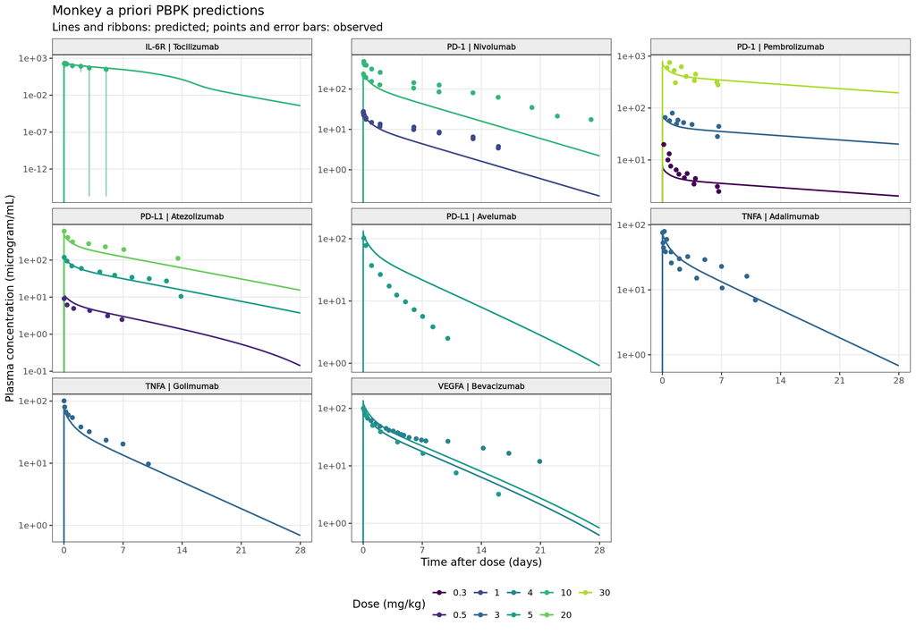

Figure 1: Monkey observed concentrations and a priori PBPK predictions.

```r
monkey_plot
```

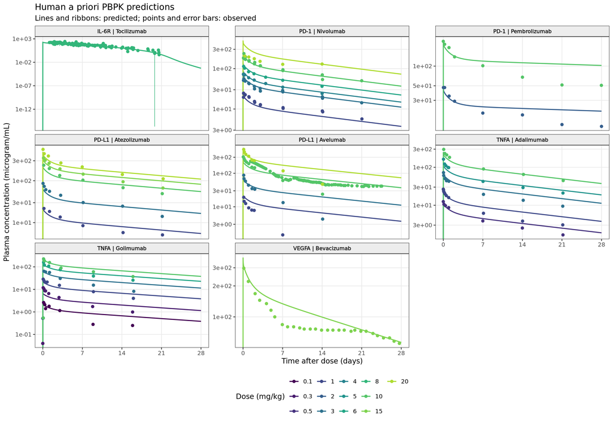

Figure 2: Human observed concentrations and a priori PBPK predictions.

```r
human_plot
```

# 5. Calculate profile-level PK metrics

Metrics are first calculated for each observed subject and each simulated individual. Scenario-level values are then arithmetic means across profiles. This preserves the distinction between within-profile noncompartmental calculation and between-profile aggregation.

For AUC0-tlast, every simulated individual is sampled at the exact time points of every corresponding observed profile. This produces paired observed and predicted AUCs with the same integration interval and sampling grid. Other predicted PK metrics continue to use the full simulated profile.

The terminal phase is selected from consecutive post-Cmax suffixes using the largest adjusted R-squared, with at least three positive concentrations. The selected number of points and terminal-phase diagnostics remain in the embedded HTML tables so questionable AUCinf estimates can be identified.

```r
metric_columns <- c(
  "Cmax_ug_mL", "AUC0_tlast_ug_h_mL", "AUClast_ug_h_mL",
  "AUCinf_ug_h_mL", "AUC_extrapolated_pct", "Lambda_z_1_h",
  "Terminal_half_life_day", "Terminal_points_n", "Last_time_h",
  "CL_L_day_kg"
)

observed_profile_metrics <- observed |>
  group_by(
    .data$Molecule, .data$Species, .data$Dose, .data$Profile_ID
  ) |>
  group_modify(~ profile_pk_metrics(
    .x$Time_h,
    .x$Conc_ug_mL,
    dose_mg_kg = .y$Dose[[1]],
    t_end_h = max(.x$Time_h, na.rm = TRUE)
  )) |>
  ungroup() |>
  mutate(
    Clearance_evaluability = case_when(
      !is.finite(.data$AUC_extrapolated_pct) ~ "Not evaluable",
      .data$AUC_extrapolated_pct > EXTRAPOLATION_THRESHOLD_PCT ~
        "Not evaluable",
      TRUE ~ "Evaluable"
    ),
    CL_L_day_kg = if_else(
      .data$Clearance_evaluability == "Evaluable",
      .data$CL_L_day_kg,
      NA_real_
    )
  )

predicted_profile_metrics <- predicted |>
  group_by(
    .data$Molecule, .data$Species, .data$Dose, .data$IndividualId
  ) |>
  group_modify(~ profile_pk_metrics(
    .x$Time_h,
    .x$Conc_ug_mL,
    dose_mg_kg = .y$Dose[[1]],
    t_end_h = Inf
  )) |>
  ungroup()

observed_sampling_schedules <- observed |>
  group_by(
    .data$Molecule, .data$Species, .data$Dose, .data$Profile_ID
  ) |>
  summarise(
    Sampling_times_h = list(sort(unique(.data$Time_h))),
    Observed_tlast_h = max(.data$Time_h),
    .groups = "drop"
  )

predicted_profiles <- predicted |>
  group_by(
    .data$Molecule, .data$Species, .data$Dose, .data$IndividualId
  ) |>
  summarise(
    Predicted_time_h = list(.data$Time_h),
    Predicted_conc_ug_mL = list(.data$Conc_ug_mL),
    .groups = "drop"
  )

predicted_auc0_tlast_profile_metrics <- observed_sampling_schedules |>
  inner_join(
    predicted_profiles,
    by = c("Molecule", "Species", "Dose"),
    relationship = "many-to-many"
  ) |>
  mutate(
    Sampled_predicted_conc = pmap(
      list(
        .data$Predicted_time_h,
        .data$Predicted_conc_ug_mL,
        .data$Sampling_times_h
      ),
      sample_profile_at_times
    ),
    Predicted_AUC0_tlast_ug_h_mL = map2_dbl(
      .data$Sampling_times_h,
      .data$Sampled_predicted_conc,
      ~ linear_up_log_down_auc(prepare_profile(.x, .y, t_end_h = max(.x)))
    )
  ) |>
  select(
    .data$Molecule, .data$Species, .data$Dose, .data$Profile_ID,
    .data$IndividualId, .data$Observed_tlast_h,
    .data$Predicted_AUC0_tlast_ug_h_mL
  )

summarize_metrics <- function(data, prefix) {
  data |>
    group_by(.data$Molecule, .data$Species, .data$Dose) |>
    summarise(
      Profiles_n = n(),
      across(all_of(metric_columns), mean_or_na),
      .groups = "drop"
    ) |>
    rename_with(
      ~ paste0(prefix, "_", .x),
      all_of(c("Profiles_n", metric_columns))
    )
}

observed_metrics <- summarize_metrics(observed_profile_metrics, "Observed")
predicted_metrics <- summarize_metrics(predicted_profile_metrics, "Predicted") |>
  select(-.data$Predicted_AUC0_tlast_ug_h_mL) |>
  left_join(
    predicted_auc0_tlast_profile_metrics |>
      group_by(.data$Molecule, .data$Species, .data$Dose) |>
      summarise(
        Predicted_AUC0_tlast_ug_h_mL =
          mean_or_na(.data$Predicted_AUC0_tlast_ug_h_mL),
        .groups = "drop"
      ),
    by = c("Molecule", "Species", "Dose")
  )

observed_clearance_evaluability <- observed_profile_metrics |>
  group_by(.data$Molecule, .data$Species, .data$Dose) |>
  summarise(
    Observed_clearance_evaluable_profiles_n =
      sum(.data$Clearance_evaluability == "Evaluable"),
    Observed_clearance_profiles_n = n(),
    Observed_Clearance_evaluability = case_when(
      Observed_clearance_evaluable_profiles_n == 0L ~ "Not evaluable",
      Observed_clearance_evaluable_profiles_n < Observed_clearance_profiles_n ~
        paste0(
          "Partially evaluable (",
          Observed_clearance_evaluable_profiles_n, "/",
          Observed_clearance_profiles_n, " profiles)"
        ),
      TRUE ~ "Evaluable"
    ),
    .groups = "drop"
  )

scenario_metrics <- full_join(
  observed_metrics,
  predicted_metrics,
  by = c("Molecule", "Species", "Dose")
) |>
  left_join(
    observed_clearance_evaluability,
    by = c("Molecule", "Species", "Dose")
  ) |>
  left_join(target_lookup, by = "Molecule") |>
  mutate(
    FE_Cmax = .data$Predicted_Cmax_ug_mL / .data$Observed_Cmax_ug_mL,
    FE_AUC0_tlast =
      .data$Predicted_AUC0_tlast_ug_h_mL /
        .data$Observed_AUC0_tlast_ug_h_mL,
    FE_Clearance = if_else(
      .data$Observed_Clearance_evaluability == "Not evaluable",
      NA_real_,
      .data$Predicted_CL_L_day_kg / .data$Observed_CL_L_day_kg
    ),
    Observed_AUC_extrapolation_flag = case_when(
      !is.finite(.data$Observed_AUC_extrapolated_pct) ~ "Not estimable",
      .data$Observed_AUC_extrapolated_pct > EXTRAPOLATION_THRESHOLD_PCT ~ ">20%",
      TRUE ~ "<=20%"
    ),
    Predicted_AUC_extrapolation_flag = case_when(
      !is.finite(.data$Predicted_AUC_extrapolated_pct) ~ "Not estimable",
      .data$Predicted_AUC_extrapolated_pct > EXTRAPOLATION_THRESHOLD_PCT ~ ">20%",
      TRUE ~ "<=20%"
    )
  ) |>
  arrange(
    factor(.data$Species, levels = c("Monkey", "Human")),
    .data$Target, .data$Molecule, .data$Dose
  )
```

# 6. Summarize predictive performance

The accuracy denominator includes only scenarios with finite observed and predicted values for the relevant metric. Observed profiles with more than 20% AUCinf extrapolation are excluded from clearance summaries; a scenario with no evaluable observed clearance profiles is reported as `Not evaluable` rather than counted as a failed prediction.

```r
accuracy_summary <- scenario_metrics |>
  select(
    .data$Species, .data$Molecule, .data$Dose,
    Cmax = .data$FE_Cmax,
    `AUC0-tlast` = .data$FE_AUC0_tlast,
    Clearance = .data$FE_Clearance
  ) |>
  pivot_longer(
    cols = c("Cmax", "AUC0-tlast", "Clearance"),
    names_to = "Metric",
    values_to = "Fold_error"
  ) |>
  filter(is.finite(.data$Fold_error)) |>
  group_by(.data$Species, .data$Metric) |>
  summarise(
    Within_two_fold = sum(within_two_fold(.data$Fold_error)),
    Evaluated = n(),
    .groups = "drop"
  ) |>
  mutate(Accuracy = .data$Within_two_fold / .data$Evaluated) |>
  arrange(
    factor(.data$Species, levels = c("Monkey", "Human")),
    match(.data$Metric, c("AUC0-tlast", "Cmax", "Clearance"))
  )

accuracy_summary |>
  mutate(Accuracy = scales::percent(.data$Accuracy, accuracy = 1)) |>
  knitr::kable(caption = "Predictions within the 0.5- to 2-fold criterion")
```

Predictions within the 0.5- to 2-fold criterion

| Species | Metric | Within_two_fold | Evaluated | Accuracy |
| --- | --- | --- | --- | --- |
| Monkey | AUC0-tlast | 12 | 14 | 86% |
| Monkey | Cmax | 13 | 14 | 93% |
| Monkey | Clearance | 3 | 6 | 50% |
| Human | AUC0-tlast | 29 | 30 | 97% |
| Human | Cmax | 29 | 30 | 97% |
| Human | Clearance | 10 | 15 | 67% |

## Monkey scenario metrics

```r
display_columns <- c(
  "Target", "Molecule", "Dose",
  "Observed_Cmax_ug_mL", "Predicted_Cmax_ug_mL", "FE_Cmax",
  "Observed_AUC0_tlast_ug_h_mL", "Predicted_AUC0_tlast_ug_h_mL",
  "FE_AUC0_tlast", "Observed_CL_L_day_kg", "Predicted_CL_L_day_kg",
  "FE_Clearance", "Observed_AUC_extrapolated_pct",
  "Observed_AUC_extrapolation_flag", "Observed_Clearance_evaluability"
)

scenario_metrics |>
  filter(.data$Species == "Monkey") |>
  select(all_of(display_columns)) |>
  mutate(across(where(is.numeric), ~ round(.x, 3))) |>
  knitr::kable(caption = "Monkey observed and a priori predicted PK metrics")
```

Monkey observed and a priori predicted PK metrics

| Target | Molecule | Dose | Observed_Cmax_ug_mL | Predicted_Cmax_ug_mL | FE_Cmax | Observed_AUC0_tlast_ug_h_mL | Predicted_AUC0_tlast_ug_h_mL | FE_AUC0_tlast | Observed_CL_L_day_kg | Predicted_CL_L_day_kg | FE_Clearance | Observed_AUC_extrapolated_pct | Observed_AUC_extrapolation_flag | Observed_Clearance_evaluability |
| --- | --- | --- | --- | --- | --- | --- | --- | --- | --- | --- | --- | --- | --- | --- |
| IL-6R | Tocilizumab | 10.0 | 250.385 | 266.614 | 1.065 | 8802.103 | 11720.173 | 1.332 | 0.065 | 0.016 | 0.237 | 14.771 | <=20% | Partially evaluable (1/2 profiles) |
| PD-1 | Nivolumab | 1.0 | 27.000 | 26.304 | 0.974 | 3603.017 | 2059.650 | 0.572 | NA | 0.011 | NA | 21.308 | >20% | Not evaluable |
| PD-1 | Nivolumab | 10.0 | 357.300 | 263.035 | 0.736 | 45382.205 | 19162.890 | 0.422 | 0.005 | 0.011 | 2.293 | 20.418 | >20% | Partially evaluable (1/2 profiles) |
| PD-1 | Pembrolizumab | 0.3 | 19.840 | 7.892 | 0.398 | 905.482 | 673.657 | 0.744 | NA | 0.002 | NA | 28.050 | >20% | Not evaluable |
| PD-1 | Pembrolizumab | 3.0 | 79.880 | 78.918 | 0.988 | 7470.089 | 6596.701 | 0.883 | NA | 0.002 | NA | 58.659 | >20% | Not evaluable |
| PD-1 | Pembrolizumab | 30.0 | 753.220 | 789.173 | 1.048 | 67054.557 | 62012.308 | 0.925 | NA | 0.002 | NA | 38.301 | >20% | Not evaluable |
| PD-L1 | Atezolizumab | 0.5 | 9.110 | 12.970 | 1.424 | 682.961 | 861.109 | 1.261 | NA | 0.008 | NA | 37.125 | >20% | Not evaluable |
| PD-L1 | Atezolizumab | 5.0 | 118.800 | 129.718 | 1.092 | 13939.584 | 12496.366 | 0.896 | 0.007 | 0.007 | 0.999 | 12.983 | <=20% | Evaluable |
| PD-L1 | Atezolizumab | 20.0 | 603.490 | 518.875 | 0.860 | 69445.128 | 48451.652 | 0.698 | NA | 0.008 | NA | 31.488 | >20% | Not evaluable |
| PD-L1 | Avelumab | 5.0 | 102.190 | 132.415 | 1.296 | 4047.335 | 8699.706 | 2.149 | 0.028 | 0.011 | 0.388 | 5.243 | <=20% | Evaluable |
| TNFA | Adalimumab | 3.0 | 66.135 | 79.992 | 1.210 | 5579.526 | 5419.805 | 0.971 | NA | 0.011 | NA | 29.387 | >20% | Not evaluable |
| TNFA | Golimumab | 3.0 | 100.730 | 81.073 | 0.805 | 6869.512 | 5421.987 | 0.789 | 0.009 | 0.010 | 1.180 | 15.549 | <=20% | Evaluable |
| VEGFA | Bevacizumab | 4.0 | 94.910 | 108.097 | 1.139 | 14142.969 | 8487.278 | 0.600 | NA | 0.011 | NA | 21.614 | >20% | Not evaluable |
| VEGFA | Bevacizumab | 5.0 | 100.000 | 135.121 | 1.351 | 7595.824 | 10346.309 | 1.362 | 0.015 | 0.011 | 0.719 | 5.375 | <=20% | Evaluable |

## Human scenario metrics

```r
scenario_metrics |>
  filter(.data$Species == "Human") |>
  select(all_of(display_columns)) |>
  mutate(across(where(is.numeric), ~ round(.x, 3))) |>
  knitr::kable(caption = "Human observed and a priori predicted PK metrics")
```

Human observed and a priori predicted PK metrics

| Target | Molecule | Dose | Observed_Cmax_ug_mL | Predicted_Cmax_ug_mL | FE_Cmax | Observed_AUC0_tlast_ug_h_mL | Predicted_AUC0_tlast_ug_h_mL | FE_AUC0_tlast | Observed_CL_L_day_kg | Predicted_CL_L_day_kg | FE_Clearance | Observed_AUC_extrapolated_pct | Observed_AUC_extrapolation_flag | Observed_Clearance_evaluability |
| --- | --- | --- | --- | --- | --- | --- | --- | --- | --- | --- | --- | --- | --- | --- |
| IL-6R | Tocilizumab | 8.0 | 273.740 | 196.835 | 0.719 | 25350.213 | 17039.784 | 0.672 | 0.008 | 0.010 | 1.310 | 0.002 | <=20% | Evaluable |
| PD-1 | Nivolumab | 1.0 | 24.375 | 24.273 | 0.996 | 4592.752 | 3751.096 | 0.817 | NA | 0.003 | NA | 50.393 | >20% | Not evaluable |
| PD-1 | Nivolumab | 3.0 | 62.375 | 72.818 | 1.167 | 10870.948 | 11213.497 | 1.032 | NA | 0.003 | NA | 45.164 | >20% | Not evaluable |
| PD-1 | Nivolumab | 4.0 | 72.640 | 97.091 | 1.337 | 12824.236 | 13057.013 | 1.018 | NA | 0.003 | NA | 44.624 | >20% | Not evaluable |
| PD-1 | Nivolumab | 6.0 | 113.460 | 145.636 | 1.284 | 18667.804 | 19462.789 | 1.043 | NA | 0.003 | NA | 47.619 | >20% | Not evaluable |
| PD-1 | Nivolumab | 10.0 | 207.975 | 242.727 | 1.167 | 37829.265 | 37219.164 | 0.984 | NA | 0.003 | NA | 42.154 | >20% | Not evaluable |
| PD-1 | Nivolumab | 20.0 | 203.440 | 485.453 | 2.386 | 47274.197 | 63141.836 | 1.336 | NA | 0.003 | NA | 69.963 | >20% | Not evaluable |
| PD-1 | Pembrolizumab | 2.0 | 47.020 | 48.547 | 1.032 | 12381.305 | 15853.616 | 1.280 | NA | 0.001 | NA | 41.798 | >20% | Not evaluable |
| PD-1 | Pembrolizumab | 10.0 | 239.070 | 242.733 | 1.015 | 55743.386 | 78506.281 | 1.408 | NA | 0.001 | NA | 35.270 | >20% | Not evaluable |
| PD-L1 | Atezolizumab | 1.0 | 21.810 | 23.935 | 1.097 | 4415.000 | 4822.561 | 1.092 | NA | 0.002 | NA | 30.741 | >20% | Not evaluable |
| PD-L1 | Atezolizumab | 3.0 | 86.500 | 71.815 | 0.830 | 15529.872 | 14571.424 | 0.938 | NA | 0.002 | NA | 24.546 | >20% | Not evaluable |
| PD-L1 | Atezolizumab | 10.0 | 234.470 | 239.394 | 1.021 | 48534.028 | 48141.432 | 0.992 | NA | 0.002 | NA | 30.663 | >20% | Not evaluable |
| PD-L1 | Atezolizumab | 15.0 | 349.390 | 359.093 | 1.028 | 67867.290 | 72406.114 | 1.067 | NA | 0.002 | NA | 30.561 | >20% | Not evaluable |
| PD-L1 | Atezolizumab | 20.0 | 559.800 | 478.792 | 0.855 | 100661.979 | 96897.131 | 0.963 | NA | 0.002 | NA | 35.259 | >20% | Not evaluable |
| PD-L1 | Avelumab | 1.0 | 19.190 | 24.434 | 1.273 | 935.309 | 2022.528 | 2.162 | 0.023 | 0.003 | 0.149 | 10.591 | <=20% | Evaluable |
| PD-L1 | Avelumab | 3.0 | 87.500 | 73.310 | 0.838 | 6227.483 | 9936.039 | 1.596 | 0.011 | 0.003 | 0.320 | 8.906 | <=20% | Evaluable |
| PD-L1 | Avelumab | 10.0 | 268.805 | 244.378 | 0.909 | 35709.356 | 38041.620 | 1.065 | 0.008 | 0.003 | 0.444 | 24.286 | >20% | Partially evaluable (1/2 profiles) |
| PD-L1 | Avelumab | 20.0 | 515.580 | 488.761 | 0.948 | 48921.982 | 65459.237 | 1.338 | 0.008 | 0.003 | 0.405 | 14.688 | <=20% | Evaluable |
| TNFA | Adalimumab | 0.5 | 12.490 | 12.302 | 0.985 | 2205.294 | 2565.770 | 1.163 | 0.004 | 0.003 | 0.748 | 18.752 | <=20% | Evaluable |
| TNFA | Adalimumab | 1.0 | 26.570 | 24.605 | 0.926 | 3772.458 | 5159.786 | 1.368 | 0.005 | 0.003 | 0.643 | 19.176 | <=20% | Evaluable |
| TNFA | Adalimumab | 3.0 | 72.310 | 73.815 | 1.021 | 11385.860 | 15440.102 | 1.356 | 0.005 | 0.003 | 0.631 | 17.001 | <=20% | Evaluable |
| TNFA | Adalimumab | 5.0 | 162.990 | 123.024 | 0.755 | 25409.662 | 25730.574 | 1.013 | NA | 0.003 | NA | 20.026 | >20% | Not evaluable |
| TNFA | Adalimumab | 10.0 | 295.490 | 246.049 | 0.833 | 52986.659 | 50951.803 | 0.962 | NA | 0.003 | NA | 21.272 | >20% | Not evaluable |
| TNFA | Golimumab | 0.1 | 2.630 | 2.494 | 0.948 | 294.688 | 528.242 | 1.793 | 0.007 | 0.003 | 0.452 | 11.471 | <=20% | Evaluable |
| TNFA | Golimumab | 0.3 | 11.870 | 7.481 | 0.630 | 1312.796 | 1587.199 | 1.209 | 0.005 | 0.003 | 0.679 | 12.492 | <=20% | Evaluable |
| TNFA | Golimumab | 1.0 | 28.520 | 24.937 | 0.874 | 4846.574 | 5296.509 | 1.093 | 0.004 | 0.003 | 0.726 | 9.204 | <=20% | Evaluable |
| TNFA | Golimumab | 3.0 | 63.850 | 74.812 | 1.172 | 10593.210 | 15860.937 | 1.497 | 0.006 | 0.003 | 0.569 | 15.569 | <=20% | Evaluable |
| TNFA | Golimumab | 6.0 | 158.820 | 149.624 | 0.942 | 31527.211 | 40057.419 | 1.271 | 0.004 | 0.003 | 0.766 | 6.342 | <=20% | Evaluable |
| TNFA | Golimumab | 10.0 | 225.490 | 249.374 | 1.106 | 48868.319 | 72544.517 | 1.484 | 0.005 | 0.003 | 0.688 | 2.655 | <=20% | Evaluable |
| VEGFA | Bevacizumab | 15.0 | 297.250 | 374.044 | 1.258 | 95798.379 | 98958.858 | 1.033 | 0.003 | 0.003 | 1.031 | 14.761 | <=20% | Evaluable |

# 7. Inspect AUCinf extrapolation

A high extrapolated fraction indicates that terminal exposure and clearance are sensitive to the selected terminal slope. An observed profile is marked `Not evaluable` for clearance when its extrapolated fraction exceeds 20% or cannot be estimated. The terminal diagnostics remain available for review.

```r
auc_extrapolation <- scenario_metrics |>
  transmute(
    .data$Species, .data$Target, .data$Molecule,
    `Dose (mg/kg)` = .data$Dose,
    `Observed profiles (n)` = .data$Observed_Profiles_n,
    `Observed last time (h)` = .data$Observed_Last_time_h,
    `Observed terminal points (mean n)` =
      .data$Observed_Terminal_points_n,
    `Observed AUCinf (ug*h/mL)` = .data$Observed_AUCinf_ug_h_mL,
    `Observed AUC extrapolated (%)` =
      .data$Observed_AUC_extrapolated_pct,
    `Observed flag` = .data$Observed_AUC_extrapolation_flag,
    `Observed clearance evaluability` =
      .data$Observed_Clearance_evaluability,
    `Predicted profiles (n)` = .data$Predicted_Profiles_n,
    `Predicted last time (h)` = .data$Predicted_Last_time_h,
    `Predicted terminal points (mean n)` =
      .data$Predicted_Terminal_points_n,
    `Predicted AUCinf (ug*h/mL)` = .data$Predicted_AUCinf_ug_h_mL,
    `Predicted AUC extrapolated (%)` =
      .data$Predicted_AUC_extrapolated_pct,
    `Predicted flag` = .data$Predicted_AUC_extrapolation_flag
  )

auc_extrapolation |>
  mutate(across(where(is.numeric), ~ round(.x, 2))) |>
  knitr::kable(caption = "AUCinf terminal-phase and extrapolation diagnostics")
```

AUCinf terminal-phase and extrapolation diagnostics

| Species | Target | Molecule | Dose (mg/kg) | Observed profiles (n) | Observed last time (h) | Observed terminal points (mean n) | Observed AUCinf (ug*h/mL) | Observed AUC extrapolated (%) | Observed flag | Observed clearance evaluability | Predicted profiles (n) | Predicted last time (h) | Predicted terminal points (mean n) | Predicted AUCinf (ug*h/mL) | Predicted AUC extrapolated (%) | Predicted flag |
| --- | --- | --- | --- | --- | --- | --- | --- | --- | --- | --- | --- | --- | --- | --- | --- | --- |
| Monkey | IL-6R | Tocilizumab | 10.0 | 2 | 120.00 | 4.0 | 11723.19 | 14.77 | <=20% | Partially evaluable (1/2 profiles) | 1 | 2880 | 362 | 15471.38 | 0.00 | <=20% |
| Monkey | PD-1 | Nivolumab | 1.0 | 2 | 384.33 | 7.0 | 4578.22 | 21.31 | >20% | Not evaluable | 1 | 2880 | 165 | 2245.04 | 0.00 | <=20% |
| Monkey | PD-1 | Nivolumab | 10.0 | 2 | 431.97 | 5.5 | 58327.60 | 20.42 | >20% | Partially evaluable (1/2 profiles) | 1 | 2880 | 108 | 22047.42 | 0.00 | <=20% |
| Monkey | PD-1 | Pembrolizumab | 0.3 | 1 | 160.08 | 9.0 | 1258.49 | 28.05 | >20% | Not evaluable | 1 | 2880 | 3 | 3870.21 | 3.77 | <=20% |
| Monkey | PD-1 | Pembrolizumab | 3.0 | 1 | 160.32 | 5.0 | 18069.45 | 58.66 | >20% | Not evaluable | 1 | 2880 | 3 | 38904.56 | 4.01 | <=20% |
| Monkey | PD-1 | Pembrolizumab | 30.0 | 1 | 158.16 | 3.0 | 108680.91 | 38.30 | >20% | Not evaluable | 1 | 2880 | 11 | 378610.07 | 4.02 | <=20% |
| Monkey | PD-L1 | Atezolizumab | 0.5 | 1 | 164.91 | 3.0 | 1086.21 | 37.12 | >20% | Not evaluable | 1 | 2880 | 188 | 1426.26 | 0.00 | <=20% |
| Monkey | PD-L1 | Atezolizumab | 5.0 | 1 | 332.73 | 9.0 | 16019.46 | 12.98 | <=20% | Evaluable | 1 | 2880 | 136 | 16039.43 | 0.00 | <=20% |
| Monkey | PD-L1 | Atezolizumab | 20.0 | 1 | 324.24 | 3.0 | 101361.59 | 31.49 | >20% | Not evaluable | 1 | 2880 | 80 | 63545.53 | 0.00 | <=20% |
| Monkey | PD-L1 | Avelumab | 5.0 | 1 | 240.50 | 6.0 | 4271.28 | 5.24 | <=20% | Evaluable | 1 | 2880 | 202 | 11009.40 | 0.00 | <=20% |
| Monkey | TNFA | Adalimumab | 3.0 | 2 | 252.13 | 3.0 | 7979.60 | 29.39 | >20% | Not evaluable | 1 | 2880 | 27 | 6801.53 | 0.00 | <=20% |
| Monkey | TNFA | Golimumab | 3.0 | 1 | 240.02 | 8.0 | 8134.35 | 15.55 | <=20% | Evaluable | 1 | 2880 | 13 | 6893.17 | 0.00 | <=20% |
| Monkey | VEGFA | Bevacizumab | 4.0 | 1 | 501.88 | 4.0 | 18042.73 | 21.61 | >20% | Not evaluable | 1 | 2880 | 154 | 8903.35 | 0.00 | <=20% |
| Monkey | VEGFA | Bevacizumab | 5.0 | 1 | 384.96 | 5.0 | 8027.26 | 5.37 | <=20% | Evaluable | 1 | 2880 | 150 | 11158.91 | 0.00 | <=20% |
| Human | IL-6R | Tocilizumab | 8.0 | 1 | 494.06 | 3.0 | 25350.74 | 0.00 | <=20% | Evaluable | 1 | 2838 | 563 | 19345.57 | 0.00 | <=20% |
| Human | PD-1 | Nivolumab | 1.0 | 2 | 420.84 | 3.5 | 9543.40 | 50.39 | >20% | Not evaluable | 1 | 2880 | 84 | 7160.40 | 0.76 | <=20% |
| Human | PD-1 | Nivolumab | 3.0 | 2 | 420.56 | 3.5 | 19855.34 | 45.16 | >20% | Not evaluable | 1 | 2880 | 35 | 21444.53 | 0.76 | <=20% |
| Human | PD-1 | Nivolumab | 4.0 | 1 | 335.88 | 3.0 | 23158.61 | 44.62 | >20% | Not evaluable | 1 | 2880 | 13 | 28568.22 | 0.76 | <=20% |
| Human | PD-1 | Nivolumab | 6.0 | 1 | 335.45 | 3.0 | 35638.60 | 47.62 | >20% | Not evaluable | 1 | 2880 | 3 | 42778.80 | 0.76 | <=20% |
| Human | PD-1 | Nivolumab | 10.0 | 2 | 420.32 | 4.5 | 66096.24 | 42.15 | >20% | Not evaluable | 1 | 2880 | 26 | 71052.25 | 0.76 | <=20% |
| Human | PD-1 | Nivolumab | 20.0 | 1 | 335.78 | 5.0 | 157385.91 | 69.96 | >20% | Not evaluable | 1 | 2880 | 7 | 140868.46 | 0.76 | <=20% |
| Human | PD-1 | Pembrolizumab | 2.0 | 1 | 672.00 | 5.0 | 21272.87 | 41.80 | >20% | Not evaluable | 1 | 2880 | 14 | 89143.64 | 44.43 | >20% |
| Human | PD-1 | Pembrolizumab | 10.0 | 1 | 671.49 | 5.0 | 86116.57 | 35.27 | >20% | Not evaluable | 1 | 2880 | 9 | 443405.10 | 44.31 | >20% |
| Human | PD-L1 | Atezolizumab | 1.0 | 1 | 508.37 | 5.0 | 6374.60 | 30.74 | >20% | Not evaluable | 1 | 2880 | 3 | 10561.11 | 2.83 | <=20% |
| Human | PD-L1 | Atezolizumab | 3.0 | 1 | 507.39 | 6.0 | 20581.84 | 24.55 | >20% | Not evaluable | 1 | 2880 | 3 | 32260.28 | 3.60 | <=20% |
| Human | PD-L1 | Atezolizumab | 10.0 | 1 | 507.39 | 4.0 | 69996.84 | 30.66 | >20% | Not evaluable | 1 | 2880 | 3 | 107725.36 | 3.88 | <=20% |
| Human | PD-L1 | Atezolizumab | 15.0 | 1 | 510.34 | 3.0 | 97736.36 | 30.56 | >20% | Not evaluable | 1 | 2880 | 3 | 161137.46 | 3.92 | <=20% |
| Human | PD-L1 | Atezolizumab | 20.0 | 1 | 511.33 | 4.0 | 155484.09 | 35.26 | >20% | Not evaluable | 1 | 2880 | 3 | 214135.50 | 3.94 | <=20% |
| Human | PD-L1 | Avelumab | 1.0 | 1 | 168.59 | 4.0 | 1046.10 | 10.59 | <=20% | Evaluable | 1 | 2880 | 3 | 7029.25 | 0.13 | <=20% |
| Human | PD-L1 | Avelumab | 3.0 | 1 | 338.11 | 4.0 | 6836.29 | 8.91 | <=20% | Evaluable | 1 | 2880 | 3 | 21394.78 | 0.49 | <=20% |
| Human | PD-L1 | Avelumab | 10.0 | 2 | 463.38 | 31.5 | 50182.57 | 24.29 | >20% | Partially evaluable (1/2 profiles) | 1 | 2880 | 3 | 71334.18 | 0.67 | <=20% |
| Human | PD-L1 | Avelumab | 20.0 | 1 | 337.38 | 4.0 | 57344.68 | 14.69 | <=20% | Evaluable | 1 | 2880 | 3 | 141623.96 | 0.71 | <=20% |
| Human | TNFA | Adalimumab | 0.5 | 1 | 674.45 | 4.0 | 2714.26 | 18.75 | <=20% | Evaluable | 1 | 2880 | 115 | 3630.63 | 0.76 | <=20% |
| Human | TNFA | Adalimumab | 1.0 | 1 | 676.27 | 4.0 | 4667.53 | 19.18 | <=20% | Evaluable | 1 | 2880 | 79 | 7258.17 | 0.76 | <=20% |
| Human | TNFA | Adalimumab | 3.0 | 1 | 676.27 | 4.0 | 13718.01 | 17.00 | <=20% | Evaluable | 1 | 2880 | 4 | 21737.33 | 0.76 | <=20% |
| Human | TNFA | Adalimumab | 5.0 | 1 | 677.18 | 4.0 | 31772.38 | 20.03 | >20% | Not evaluable | 1 | 2880 | 23 | 36166.81 | 0.76 | <=20% |
| Human | TNFA | Adalimumab | 10.0 | 1 | 676.27 | 3.0 | 67303.66 | 21.27 | >20% | Not evaluable | 1 | 2880 | 5 | 72022.38 | 0.76 | <=20% |
| Human | TNFA | Golimumab | 0.1 | 1 | 719.04 | 3.0 | 332.87 | 11.47 | <=20% | Evaluable | 1 | 2880 | 218 | 736.19 | 0.76 | <=20% |
| Human | TNFA | Golimumab | 0.3 | 1 | 720.72 | 3.0 | 1500.20 | 12.49 | <=20% | Evaluable | 1 | 2880 | 152 | 2208.19 | 0.76 | <=20% |
| Human | TNFA | Golimumab | 1.0 | 1 | 720.72 | 6.0 | 5337.87 | 9.20 | <=20% | Evaluable | 1 | 2880 | 79 | 7356.25 | 0.76 | <=20% |
| Human | TNFA | Golimumab | 3.0 | 1 | 724.08 | 3.0 | 12546.63 | 15.57 | <=20% | Evaluable | 1 | 2880 | 34 | 22031.08 | 0.76 | <=20% |
| Human | TNFA | Golimumab | 6.0 | 1 | 1391.04 | 3.0 | 33662.10 | 6.34 | <=20% | Evaluable | 1 | 2880 | 4 | 43948.87 | 0.76 | <=20% |
| Human | TNFA | Golimumab | 10.0 | 1 | 2735.04 | 7.0 | 50201.15 | 2.65 | <=20% | Evaluable | 1 | 2880 | 25 | 72995.65 | 0.76 | <=20% |
| Human | VEGFA | Bevacizumab | 15.0 | 1 | 1414.57 | 4.0 | 112388.51 | 14.76 | <=20% | Evaluable | 1 | 2880 | 21 | 109012.59 | 0.76 | <=20% |

# 8. Present the complete analysis record in this HTML

No figures or tables are written to companion files. Everything needed to review the evaluation is embedded below and will remain inside the single HTML created by Quarto.

## Analysis settings

```r
analysis_record <- data.frame(
  Field = c(
    "Simulation result folder", "Analysis date", "Comparison AUC interval",
    "Predicted comparison AUC sampling",
    "AUC extrapolation flag threshold (%)",
    "Observed concentration unit", "Predicted concentration conversion"
  ),
  Value = c(
    basename(results_folder), as.character(Sys.Date()),
    "0 to each observed profile's last sampling time",
    "Predicted profile interpolated at observed sampling times",
    EXTRAPOLATION_THRESHOLD_PCT, "microgram/mL",
    "micromol/L multiplied by molecular weight (g/mol) divided by 1000"
  ),
  stringsAsFactors = FALSE
)

analysis_record |>
  knitr::kable(caption = "Analysis settings embedded in this report")
```

Analysis settings embedded in this report

| Field | Value |
| --- | --- |
| Simulation result folder | 2026-10-27 08-26 |
| Analysis date | 2026-10-27 |
| Comparison AUC interval | 0 to each observed profile’s last sampling time |
| Predicted comparison AUC sampling | Predicted profile interpolated at observed sampling times |
| AUC extrapolation flag threshold (%) | 20 |
| Observed concentration unit | microgram/mL |
| Predicted concentration conversion | micromol/L multiplied by molecular weight (g/mol) divided by 1000 |

## Complete scenario-level metrics

```r
scenario_metrics |>
  mutate(across(where(is.numeric), ~ round(.x, 4))) |>
  knitr::kable(
    caption = "Complete observed and predicted scenario-level PK metrics",
    row.names = FALSE
  )
```

Complete observed and predicted scenario-level PK metrics

| Molecule | Species | Dose | Observed_Profiles_n | Observed_Cmax_ug_mL | Observed_AUC0_tlast_ug_h_mL | Observed_AUClast_ug_h_mL | Observed_AUCinf_ug_h_mL | Observed_AUC_extrapolated_pct | Observed_Lambda_z_1_h | Observed_Terminal_half_life_day | Observed_Terminal_points_n | Observed_Last_time_h | Observed_CL_L_day_kg | Predicted_Profiles_n | Predicted_Cmax_ug_mL | Predicted_AUClast_ug_h_mL | Predicted_AUCinf_ug_h_mL | Predicted_AUC_extrapolated_pct | Predicted_Lambda_z_1_h | Predicted_Terminal_half_life_day | Predicted_Terminal_points_n | Predicted_Last_time_h | Predicted_CL_L_day_kg | Predicted_AUC0_tlast_ug_h_mL | Observed_clearance_evaluable_profiles_n | Observed_clearance_profiles_n | Observed_Clearance_evaluability | Target | FE_Cmax | … |
| --- | --- | --- | --- | --- | --- | --- | --- | --- | --- | --- | --- | --- | --- | --- | --- | --- | --- | --- | --- | --- | --- | --- | --- | --- | --- | --- | --- | --- | --- | --- |
| Tocilizumab | Monkey | 10.0 | 2 | 250.385 | 8802.1031 | 8802.1031 | 11723.1878 | 14.7711 | 0.0461 | 1.5695 | 4.0 | 120.000 | 0.0654 | 1 | 266.6137 | 15471.3798 | 15471.3798 | 0.0000 | 0.0195 | 1.4806 | 362 | 2880 | 0.0155 | 11720.1734 | 1 | 2 | Partially evaluable (1/2 profiles) | IL-6R | 1.0648 | … |
| Nivolumab | Monkey | 1.0 | 2 | 27.000 | 3603.0174 | 3603.0174 | 4578.2190 | 21.3081 | 0.0037 | 7.7916 | 7.0 | 384.330 | NA | 1 | 26.3036 | 2245.0421 | 2245.0422 | 0.0000 | 0.0059 | 4.8864 | 165 | 2880 | 0.0107 | 2059.6500 | 0 | 2 | Not evaluable | PD-1 | 0.9742 | … |
| Nivolumab | Monkey | 10.0 | 2 | 357.300 | 45382.2055 | 45382.2055 | 58327.6050 | 20.4184 | 0.0053 | 5.5186 | 5.5 | 431.975 | 0.0047 | 1 | 263.0349 | 22047.4182 | 22047.4190 | 0.0000 | 0.0059 | 4.8864 | 108 | 2880 | 0.0109 | 19162.8903 | 1 | 2 | Partially evaluable (1/2 profiles) | PD-1 | 0.7362 | … |
| Pembrolizumab | Monkey | 0.3 | 1 | 19.840 | 905.4822 | 905.4822 | 1258.4897 | 28.0501 | 0.0070 | 4.1276 | 9.0 | 160.080 | NA | 1 | 7.8918 | 3724.4812 | 3870.2140 | 3.7655 | 0.0011 | 25.1502 | 3 | 2880 | 0.0019 | 673.6572 | 0 | 1 | Not evaluable | PD-1 | 0.3978 | … |
| Pembrolizumab | Monkey | 3.0 | 1 | 79.880 | 7470.0887 | 7470.0887 | 18069.4524 | 58.6590 | 0.0042 | 6.9118 | 5.0 | 160.320 | NA | 1 | 78.9180 | 37344.3654 | 38904.5606 | 4.0103 | 0.0011 | 25.9229 | 3 | 2880 | 0.0019 | 6596.7007 | 0 | 1 | Not evaluable | PD-1 | 0.9880 | … |
| Pembrolizumab | Monkey | 30.0 | 1 | 753.220 | 67054.5568 | 67054.5568 | 108680.9115 | 38.3014 | 0.0067 | 4.3036 | 3.0 | 158.160 | NA | 1 | 789.1727 | 363397.7215 | 378610.0673 | 4.0179 | 0.0011 | 26.0607 | 11 | 2880 | 0.0019 | 62012.3075 | 0 | 1 | Not evaluable | PD-1 | 1.0477 | … |
| Atezolizumab | Monkey | 0.5 | 1 | 9.110 | 682.9612 | 682.9612 | 1086.2126 | 37.1245 | 0.0062 | 4.6961 | 3.0 | 164.910 | NA | 1 | 12.9703 | 1426.2588 | 1426.2588 | 0.0000 | 0.0189 | 1.5272 | 188 | 2880 | 0.0084 | 861.1095 | 0 | 1 | Not evaluable | PD-L1 | 1.4237 | … |
| Atezolizumab | Monkey | 5.0 | 1 | 118.800 | 13939.5837 | 13939.5837 | 16019.4621 | 12.9834 | 0.0050 | 5.7318 | 9.0 | 332.730 | 0.0075 | 1 | 129.7176 | 16039.4261 | 16039.4261 | 0.0000 | 0.0189 | 1.5272 | 136 | 2880 | 0.0075 | 12496.3665 | 1 | 1 | Evaluable | PD-L1 | 1.0919 | … |
| Atezolizumab | Monkey | 20.0 | 1 | 603.490 | 69445.1279 | 69445.1279 | 101361.5910 | 31.4877 | 0.0035 | 8.2590 | 3.0 | 324.240 | NA | 1 | 518.8752 | 63545.5302 | 63545.5302 | 0.0000 | 0.0189 | 1.5272 | 80 | 2880 | 0.0076 | 48451.6523 | 0 | 1 | Not evaluable | PD-L1 | 0.8598 | … |
| Avelumab | Monkey | 5.0 | 1 | 102.190 | 4047.3352 | 4047.3352 | 4271.2808 | 5.2431 | 0.0112 | 2.5768 | 6.0 | 240.500 | 0.0281 | 1 | 132.4149 | 11009.4024 | 11009.4024 | 0.0000 | 0.0193 | 1.4926 | 202 | 2880 | 0.0109 | 8699.7060 | 1 | 1 | Evaluable | PD-L1 | 1.2958 | … |
| Adalimumab | Monkey | 3.0 | 2 | 66.135 | 5579.5257 | 5579.5257 | 7979.5991 | 29.3869 | 0.0048 | 6.0504 | 3.0 | 252.130 | NA | 1 | 79.9919 | 6801.5308 | 6801.5310 | 0.0000 | 0.0061 | 4.7158 | 27 | 2880 | 0.0106 | 5419.8047 | 0 | 2 | Not evaluable | TNFA | 1.2095 | … |
| Golimumab | Monkey | 3.0 | 1 | 100.730 | 6869.5116 | 6869.5116 | 8134.3544 | 15.5494 | 0.0077 | 3.7621 | 8.0 | 240.020 | 0.0089 | 1 | 81.0729 | 6893.1679 | 6893.1680 | 0.0000 | 0.0070 | 4.1292 | 13 | 2880 | 0.0104 | 5421.9867 | 1 | 1 | Evaluable | TNFA | 0.8049 | … |
| Bevacizumab | Monkey | 4.0 | 1 | 94.910 | 14142.9687 | 14142.9687 | 18042.7307 | 21.6140 | 0.0031 | 9.4330 | 4.0 | 501.880 | NA | 1 | 108.0970 | 8903.3505 | 8903.3505 | 0.0000 | 0.0126 | 2.2918 | 154 | 2880 | 0.0108 | 8487.2785 | 0 | 1 | Not evaluable | VEGFA | 1.1389 | … |
| Bevacizumab | Monkey | 5.0 | 1 | 100.000 | 7595.8239 | 7595.8239 | 8027.2556 | 5.3746 | 0.0074 | 3.8817 | 5.0 | 384.960 | 0.0149 | 1 | 135.1212 | 11158.9128 | 11158.9128 | 0.0000 | 0.0126 | 2.2918 | 150 | 2880 | 0.0108 | 10346.3088 | 1 | 1 | Evaluable | VEGFA | 1.3512 | … |
| Tocilizumab | Human | 8.0 | 1 | 273.740 | 25350.2128 | 25350.2128 | 25350.7389 | 0.0021 | 0.7793 | 0.0371 | 3.0 | 494.060 | 0.0076 | 1 | 196.8347 | 19345.5696 | 19345.5696 | 0.0000 | 0.0268 | 1.0757 | 563 | 2838 | 0.0099 | 17039.7838 | 1 | 1 | Evaluable | IL-6R | 0.7191 | … |
| Nivolumab | Human | 1.0 | 2 | 24.375 | 4592.7516 | 4592.7516 | 9543.4003 | 50.3933 | 0.0016 | 18.9703 | 3.5 | 420.840 | NA | 1 | 24.2727 | 7105.8411 | 7160.4030 | 0.7620 | 0.0017 | 17.2169 | 84 | 2880 | 0.0034 | 3751.0963 | 0 | 2 | Not evaluable | PD-1 | 0.9958 | … |
| Nivolumab | Human | 3.0 | 2 | 62.375 | 10870.9476 | 10870.9476 | 19855.3434 | 45.1637 | 0.0019 | 15.1943 | 3.5 | 420.560 | NA | 1 | 72.8180 | 21281.1788 | 21444.5299 | 0.7617 | 0.0017 | 17.2168 | 35 | 2880 | 0.0034 | 11213.4971 | 0 | 2 | Not evaluable | PD-1 | 1.1674 | … |
| Nivolumab | Human | 4.0 | 1 | 72.640 | 12824.2357 | 12824.2357 | 23158.6081 | 44.6243 | 0.0023 | 12.3436 | 3.0 | 335.880 | NA | 1 | 97.0907 | 28350.6453 | 28568.2238 | 0.7616 | 0.0017 | 17.2168 | 13 | 2880 | 0.0034 | 13057.0128 | 0 | 1 | Not evaluable | PD-1 | 1.3366 | … |
| Nivolumab | Human | 6.0 | 1 | 113.460 | 18667.8038 | 18667.8038 | 35638.5983 | 47.6191 | 0.0021 | 13.4357 | 3.0 | 335.450 | NA | 1 | 145.6361 | 42453.0982 | 42778.7973 | 0.7614 | 0.0017 | 17.2168 | 3 | 2880 | 0.0034 | 19462.7891 | 0 | 1 | Not evaluable | PD-1 | 1.2836 | … |
| Nivolumab | Human | 10.0 | 2 | 207.975 | 37829.2648 | 37829.2648 | 66096.2385 | 42.1537 | 0.0022 | 13.3190 | 4.5 | 420.320 | NA | 1 | 242.7267 | 70511.6500 | 71052.2515 | 0.7609 | 0.0017 | 17.2167 | 26 | 2880 | 0.0034 | 37219.1639 | 0 | 2 | Not evaluable | PD-1 | 1.1671 | … |
| Nivolumab | Human | 20.0 | 1 | 203.440 | 47274.1966 | 47274.1966 | 157385.9106 | 69.9629 | 0.0012 | 24.5174 | 5.0 | 335.780 | NA | 1 | 485.4530 | 139798.3906 | 140868.4632 | 0.7596 | 0.0017 | 17.2166 | 7 | 2880 | 0.0034 | 63141.8363 | 0 | 1 | Not evaluable | PD-1 | 2.3862 | … |
| Pembrolizumab | Human | 2.0 | 1 | 47.020 | 12381.3047 | 12381.3047 | 21272.8699 | 41.7977 | 0.0013 | 21.3999 | 5.0 | 672.000 | NA | 1 | 48.5467 | 49537.0711 | 89143.6386 | 44.4301 | 0.0003 | 103.3829 | 14 | 2880 | 0.0005 | 15853.6162 | 0 | 1 | Not evaluable | PD-1 | 1.0325 | … |
| Pembrolizumab | Human | 10.0 | 1 | 239.070 | 55743.3864 | 55743.3864 | 86116.5721 | 35.2698 | 0.0017 | 17.2544 | 5.0 | 671.490 | NA | 1 | 242.7334 | 246939.0733 | 443405.0967 | 44.3085 | 0.0003 | 103.0731 | 9 | 2880 | 0.0005 | 78506.2813 | 0 | 1 | Not evaluable | PD-1 | 1.0153 | … |
| Atezolizumab | Human | 1.0 | 1 | 21.810 | 4414.9998 | 4414.9998 | 6374.5967 | 30.7407 | 0.0026 | 11.0754 | 5.0 | 508.370 | NA | 1 | 23.9353 | 10262.4195 | 10561.1129 | 2.8282 | 0.0013 | 21.5341 | 3 | 2880 | 0.0023 | 4822.5609 | 0 | 1 | Not evaluable | PD-L1 | 1.0974 | … |
| Atezolizumab | Human | 3.0 | 1 | 86.500 | 15529.8720 | 15529.8720 | 20581.8419 | 24.5458 | 0.0028 | 10.3407 | 6.0 | 507.390 | NA | 1 | 71.8150 | 31099.3624 | 32260.2844 | 3.5986 | 0.0012 | 24.5628 | 3 | 2880 | 0.0022 | 14571.4237 | 0 | 1 | Not evaluable | PD-L1 | 0.8302 | … |
| Atezolizumab | Human | 10.0 | 1 | 234.470 | 48534.0284 | 48534.0284 | 69996.8431 | 30.6625 | 0.0023 | 12.5709 | 4.0 | 507.390 | NA | 1 | 239.3939 | 103542.0522 | 107725.3579 | 3.8833 | 0.0011 | 25.6417 | 3 | 2880 | 0.0022 | 48141.4316 | 0 | 1 | Not evaluable | PD-L1 | 1.0210 | … |
| Atezolizumab | Human | 15.0 | 1 | 349.390 | 67867.2898 | 67867.2898 | 97736.3570 | 30.5609 | 0.0022 | 12.8543 | 3.0 | 510.340 | NA | 1 | 359.0929 | 154819.5532 | 161137.4570 | 3.9208 | 0.0011 | 25.7951 | 3 | 2880 | 0.0022 | 72406.1139 | 0 | 1 | Not evaluable | PD-L1 | 1.0278 | … |
| Atezolizumab | Human | 20.0 | 1 | 559.800 | 100661.9787 | 100661.9787 | 155484.0915 | 35.2590 | 0.0020 | 14.2015 | 4.0 | 511.330 | NA | 1 | 478.7920 | 205704.6283 | 214135.5004 | 3.9372 | 0.0011 | 25.8708 | 3 | 2880 | 0.0022 | 96897.1306 | 0 | 1 | Not evaluable | PD-L1 | 0.8553 | … |
| Avelumab | Human | 1.0 | 1 | 19.190 | 935.3092 | 935.3092 | 1046.0964 | 10.5905 | 0.0131 | 2.2067 | 4.0 | 168.590 | 0.0229 | 1 | 24.4337 | 7019.9009 | 7029.2457 | 0.1329 | 0.0040 | 7.2939 | 3 | 2880 | 0.0034 | 2022.5281 | 1 | 1 | Evaluable | PD-L1 | 1.2733 | … |
| Avelumab | Human | 3.0 | 1 | 87.500 | 6227.4828 | 6227.4828 | 6836.2940 | 8.9056 | 0.0071 | 4.0891 | 4.0 | 338.110 | 0.0105 | 1 | 73.3103 | 21290.9124 | 21394.7822 | 0.4855 | 0.0021 | 13.7052 | 3 | 2880 | 0.0034 | 9936.0386 | 1 | 1 | Evaluable | PD-L1 | 0.8378 | … |
| Avelumab | Human | 10.0 | 2 | 268.805 | 35709.3565 | 35709.3565 | 50182.5748 | 24.2860 | 0.0040 | 11.0970 | 31.5 | 463.380 | 0.0076 | 1 | 244.3784 | 70856.0391 | 71334.1817 | 0.6703 | 0.0018 | 16.1407 | 3 | 2880 | 0.0034 | 38041.6202 | 1 | 2 | Partially evaluable (1/2 profiles) | PD-L1 | 0.9091 | … |
| Avelumab | Human | 20.0 | 1 | 515.580 | 48921.9820 | 48921.9820 | 57344.6807 | 14.6878 | 0.0056 | 5.1669 | 4.0 | 337.380 | 0.0084 | 1 | 488.7611 | 140614.0239 | 141623.9580 | 0.7131 | 0.0017 | 16.6712 | 3 | 2880 | 0.0034 | 65459.2368 | 1 | 1 | Evaluable | PD-L1 | 0.9480 | … |
| Adalimumab | Human | 0.5 | 1 | 12.490 | 2205.2943 | 2205.2943 | 2714.2596 | 18.7515 | 0.0023 | 12.3525 | 4.0 | 674.450 | 0.0044 | 1 | 12.3024 | 3602.9713 | 3630.6327 | 0.7619 | 0.0017 | 17.2161 | 115 | 2880 | 0.0033 | 2565.7696 | 1 | 1 | Evaluable | TNFA | 0.9850 | … |
| Adalimumab | Human | 1.0 | 1 | 26.570 | 3772.4580 | 3772.4580 | 4667.5257 | 19.1765 | 0.0022 | 13.2567 | 4.0 | 676.270 | 0.0051 | 1 | 24.6049 | 7202.8756 | 7258.1702 | 0.7618 | 0.0017 | 17.2161 | 79 | 2880 | 0.0033 | 5159.7865 | 1 | 1 | Evaluable | TNFA | 0.9260 | … |
| Adalimumab | Human | 3.0 | 1 | 72.310 | 11385.8605 | 11385.8605 | 13718.0144 | 17.0007 | 0.0024 | 11.9636 | 4.0 | 676.270 | 0.0052 | 1 | 73.8147 | 21571.7850 | 21737.3296 | 0.7616 | 0.0017 | 17.2161 | 4 | 2880 | 0.0033 | 15440.1025 | 1 | 1 | Evaluable | TNFA | 1.0208 | … |
| Adalimumab | Human | 5.0 | 1 | 162.990 | 25409.6617 | 25409.6617 | 31772.3765 | 20.0259 | 0.0022 | 13.2680 | 4.0 | 677.180 | NA | 1 | 123.0244 | 35891.4706 | 36166.8130 | 0.7613 | 0.0017 | 17.2160 | 23 | 2880 | 0.0033 | 25730.5736 | 0 | 1 | Not evaluable | TNFA | 0.7548 | … |
| Adalimumab | Human | 10.0 | 1 | 295.490 | 52986.6589 | 52986.6589 | 67303.6572 | 21.2722 | 0.0022 | 13.2487 | 3.0 | 676.270 | NA | 1 | 246.0488 | 71474.5141 | 72022.3750 | 0.7607 | 0.0017 | 17.2159 | 5 | 2880 | 0.0033 | 50951.8031 | 0 | 1 | Not evaluable | TNFA | 0.8327 | … |
| Golimumab | Human | 0.1 | 1 | 2.630 | 294.6882 | 294.6882 | 332.8737 | 11.4715 | 0.0024 | 12.2538 | 3.0 | 719.040 | 0.0072 | 1 | 2.4937 | 730.5806 | 736.1899 | 0.7619 | 0.0017 | 17.2161 | 218 | 2880 | 0.0033 | 528.2421 | 1 | 1 | Evaluable | TNFA | 0.9482 | … |
| Golimumab | Human | 0.3 | 1 | 11.870 | 1312.7964 | 1312.7964 | 1500.2048 | 12.4922 | 0.0025 | 11.5161 | 3.0 | 720.720 | 0.0048 | 1 | 7.4812 | 2191.3690 | 2208.1935 | 0.7619 | 0.0017 | 17.2161 | 152 | 2880 | 0.0033 | 1587.1987 | 1 | 1 | Evaluable | TNFA | 0.6303 | … |
| Golimumab | Human | 1.0 | 1 | 28.520 | 4846.5735 | 4846.5735 | 5337.8739 | 9.2040 | 0.0036 | 8.0621 | 6.0 | 720.720 | 0.0045 | 1 | 24.9374 | 7300.2118 | 7356.2536 | 0.7618 | 0.0017 | 17.2161 | 79 | 2880 | 0.0033 | 5296.5092 | 1 | 1 | Evaluable | TNFA | 0.8744 | … |
| Golimumab | Human | 3.0 | 1 | 63.850 | 10593.2100 | 10593.2100 | 12546.6266 | 15.5693 | 0.0023 | 12.4541 | 3.0 | 724.080 | 0.0057 | 1 | 74.8122 | 21863.2957 | 22031.0772 | 0.7616 | 0.0017 | 17.2161 | 34 | 2880 | 0.0033 | 15860.9373 | 1 | 1 | Evaluable | TNFA | 1.1717 | … |
| Golimumab | Human | 6.0 | 1 | 158.820 | 31527.2114 | 31527.2114 | 33662.1017 | 6.3421 | 0.0018 | 15.6493 | 3.0 | 1391.040 | 0.0043 | 1 | 149.6243 | 43614.3402 | 43948.8727 | 0.7612 | 0.0017 | 17.2160 | 4 | 2880 | 0.0033 | 40057.4194 | 1 | 1 | Evaluable | TNFA | 0.9421 | … |
| Golimumab | Human | 10.0 | 1 | 225.490 | 48868.3190 | 48868.3190 | 50201.1510 | 2.6550 | 0.0015 | 19.7404 | 7.0 | 2735.040 | 0.0048 | 1 | 249.3737 | 72440.3859 | 72995.6499 | 0.7607 | 0.0017 | 17.2159 | 25 | 2880 | 0.0033 | 72544.5169 | 1 | 1 | Evaluable | TNFA | 1.1059 | … |
| Bevacizumab | Human | 15.0 | 1 | 297.250 | 95798.3786 | 95798.3786 | 112388.5139 | 14.7614 | 0.0017 | 16.5221 | 4.0 | 1414.570 | 0.0032 | 1 | 374.0444 | 108184.0948 | 109012.5879 | 0.7600 | 0.0017 | 17.2155 | 21 | 2880 | 0.0033 | 98958.8580 | 1 | 1 | Evaluable | VEGFA | 1.2583 | … |

## Complete observed profile-level metrics

```r
observed_profile_metrics |>
  mutate(across(where(is.numeric), ~ round(.x, 4))) |>
  knitr::kable(
    caption = "Observed profile-level calculations",
    row.names = FALSE
  )
```

Observed profile-level calculations

| Molecule | Species | Dose | Profile_ID | Cmax_ug_mL | AUC0_tlast_ug_h_mL | AUClast_ug_h_mL | AUCinf_ug_h_mL | AUC_extrapolated_pct | Lambda_z_1_h | Terminal_half_life_day | Terminal_points_n | Last_time_h | CL_L_day_kg | Clearance_evaluability |
| --- | --- | --- | --- | --- | --- | --- | --- | --- | --- | --- | --- | --- | --- | --- |
| Adalimumab | Human | 0.5 | Broeder 2001 Fig 1 \| 4001 | 12.49 | 2205.2943 | 2205.2943 | 2714.2596 | 18.7515 | 0.0023 | 12.3525 | 4 | 674.45 | 0.0044 | Evaluable |
| Adalimumab | Human | 1.0 | Broeder 2001 Fig 1 \| 4003 | 26.57 | 3772.4580 | 3772.4580 | 4667.5257 | 19.1765 | 0.0022 | 13.2567 | 4 | 676.27 | 0.0051 | Evaluable |
| Adalimumab | Human | 3.0 | Broeder 2001 Fig 1 \| 4004 | 72.31 | 11385.8605 | 11385.8605 | 13718.0144 | 17.0007 | 0.0024 | 11.9636 | 4 | 676.27 | 0.0052 | Evaluable |
| Adalimumab | Human | 5.0 | Broeder 2001 Fig 1 \| 4005 | 162.99 | 25409.6617 | 25409.6617 | 31772.3765 | 20.0259 | 0.0022 | 13.2680 | 4 | 677.18 | NA | Not evaluable |
| Adalimumab | Human | 10.0 | Broeder 2001 Fig 1 \| 4007 | 295.49 | 52986.6589 | 52986.6589 | 67303.6572 | 21.2722 | 0.0022 | 13.2487 | 3 | 676.27 | NA | Not evaluable |
| Adalimumab | Monkey | 3.0 | Schlereth 2016 Fig 2B \| 70 | 79.29 | 7129.2877 | 7129.2877 | 10428.6417 | 31.6374 | 0.0049 | 5.8820 | 3 | 240.02 | NA | Not evaluable |
| Adalimumab | Monkey | 3.0 | Tajiri 2024 Fig 1 \| 67 | 52.98 | 4029.7638 | 4029.7638 | 5530.5564 | 27.1364 | 0.0046 | 6.2187 | 3 | 264.24 | NA | Not evaluable |
| Atezolizumab | Human | 1.0 | Chen 2024 Fig 1 \| 1001 | 21.81 | 4414.9998 | 4414.9998 | 6374.5967 | 30.7407 | 0.0026 | 11.0754 | 5 | 508.37 | NA | Not evaluable |
| Atezolizumab | Human | 3.0 | Chen 2024 Fig 1 \| 1002 | 86.50 | 15529.8720 | 15529.8720 | 20581.8419 | 24.5458 | 0.0028 | 10.3407 | 6 | 507.39 | NA | Not evaluable |
| Atezolizumab | Human | 10.0 | Chen 2024 Fig 1 \| 1003 | 234.47 | 48534.0284 | 48534.0284 | 69996.8431 | 30.6625 | 0.0023 | 12.5709 | 4 | 507.39 | NA | Not evaluable |
| Atezolizumab | Human | 15.0 | Chen 2024 Fig 1 \| 1004 | 349.39 | 67867.2898 | 67867.2898 | 97736.3570 | 30.5609 | 0.0022 | 12.8543 | 3 | 510.34 | NA | Not evaluable |
| Atezolizumab | Human | 20.0 | Chen 2024 Fig 1 \| 1005 | 559.80 | 100661.9787 | 100661.9787 | 155484.0915 | 35.2590 | 0.0020 | 14.2015 | 4 | 511.33 | NA | Not evaluable |
| Atezolizumab | Monkey | 0.5 | Chen 2024 Supp Fig 1 \| 1 | 9.11 | 682.9612 | 682.9612 | 1086.2126 | 37.1245 | 0.0062 | 4.6961 | 3 | 164.91 | NA | Not evaluable |
| Atezolizumab | Monkey | 5.0 | Chen 2024 Supp Fig 1 \| 2 | 118.80 | 13939.5837 | 13939.5837 | 16019.4621 | 12.9834 | 0.0050 | 5.7318 | 9 | 332.73 | 0.0075 | Evaluable |
| Atezolizumab | Monkey | 20.0 | Chen 2024 Supp Fig 1 \| 3 | 603.49 | 69445.1279 | 69445.1279 | 101361.5910 | 31.4877 | 0.0035 | 8.2590 | 3 | 324.24 | NA | Not evaluable |
| Avelumab | Human | 1.0 | Chen 2024 Fig 1 \| 1006 | 19.19 | 935.3092 | 935.3092 | 1046.0964 | 10.5905 | 0.0131 | 2.2067 | 4 | 168.59 | 0.0229 | Evaluable |
| Avelumab | Human | 3.0 | Chen 2024 Fig 1 \| 1007 | 87.50 | 6227.4828 | 6227.4828 | 6836.2940 | 8.9056 | 0.0071 | 4.0891 | 4 | 338.11 | 0.0105 | Evaluable |
| Avelumab | Human | 10.0 | Chen 2024 Fig 1 \| 1008 | 308.72 | 27892.4713 | 27892.4713 | 31673.0069 | 11.9361 | 0.0063 | 4.5954 | 4 | 337.65 | 0.0076 | Evaluable |
| Avelumab | Human | 10.0 | Wilkins 2019 Fig 2 \| 2004 | 228.89 | 43526.2417 | 43526.2417 | 68692.1427 | 36.6358 | 0.0016 | 17.5985 | 59 | 589.11 | NA | Not evaluable |
| Avelumab | Human | 20.0 | Chen 2024 Fig 1 \| 1009 | 515.58 | 48921.9820 | 48921.9820 | 57344.6807 | 14.6878 | 0.0056 | 5.1669 | 4 | 337.38 | 0.0084 | Evaluable |
| Avelumab | Monkey | 5.0 | Chen 2024 Supp Fig 1 \| 14 | 102.19 | 4047.3352 | 4047.3352 | 4271.2808 | 5.2431 | 0.0112 | 2.5768 | 6 | 240.50 | 0.0281 | Evaluable |
| Bevacizumab | Human | 15.0 | Han 2016 Fig 1b \| 2010 | 297.25 | 95798.3786 | 95798.3786 | 112388.5139 | 14.7614 | 0.0017 | 16.5221 | 4 | 1414.57 | 0.0032 | Evaluable |
| Bevacizumab | Monkey | 4.0 | Pasquiers 2023 Fig 3a \| 38 | 94.91 | 14142.9687 | 14142.9687 | 18042.7307 | 21.6140 | 0.0031 | 9.4330 | 4 | 501.88 | NA | Not evaluable |
| Bevacizumab | Monkey | 5.0 | Tajiri 2024 Fig 1 \| 68 | 100.00 | 7595.8239 | 7595.8239 | 8027.2556 | 5.3746 | 0.0074 | 3.8817 | 5 | 384.96 | 0.0149 | Evaluable |
| Golimumab | Human | 0.1 | Zhou 2007 Fig 1 \| 3001 | 2.63 | 294.6882 | 294.6882 | 332.8737 | 11.4715 | 0.0024 | 12.2538 | 3 | 719.04 | 0.0072 | Evaluable |
| Golimumab | Human | 0.3 | Zhou 2007 Fig 1 \| 3002 | 11.87 | 1312.7964 | 1312.7964 | 1500.2048 | 12.4922 | 0.0025 | 11.5161 | 3 | 720.72 | 0.0048 | Evaluable |
| Golimumab | Human | 1.0 | Zhou 2007 Fig 1 \| 3003 | 28.52 | 4846.5735 | 4846.5735 | 5337.8739 | 9.2040 | 0.0036 | 8.0621 | 6 | 720.72 | 0.0045 | Evaluable |
| Golimumab | Human | 3.0 | Zhou 2007 Fig 1 \| 3004 | 63.85 | 10593.2100 | 10593.2100 | 12546.6266 | 15.5693 | 0.0023 | 12.4541 | 3 | 724.08 | 0.0057 | Evaluable |
| Golimumab | Human | 6.0 | Zhou 2007 Fig 1 \| 3005 | 158.82 | 31527.2114 | 31527.2114 | 33662.1017 | 6.3421 | 0.0018 | 15.6493 | 3 | 1391.04 | 0.0043 | Evaluable |
| Golimumab | Human | 10.0 | Zhou 2007 Fig 1 \| 3006 | 225.49 | 48868.3190 | 48868.3190 | 50201.1510 | 2.6550 | 0.0015 | 19.7404 | 7 | 2735.04 | 0.0048 | Evaluable |
| Golimumab | Monkey | 3.0 | Schlereth 2016 Fig 2B \| 71 | 100.73 | 6869.5116 | 6869.5116 | 8134.3544 | 15.5494 | 0.0077 | 3.7621 | 8 | 240.02 | 0.0089 | Evaluable |
| Nivolumab | Human | 1.0 | Chen 2024 Fig 1 \| 1010 | 24.68 | 4072.9959 | 4072.9959 | 10750.1301 | 62.1121 | 0.0013 | 21.5467 | 3 | 336.76 | NA | Not evaluable |
| Nivolumab | Human | 1.0 | Kim 2018 Fig 1 \| 2001 | 24.07 | 5112.5072 | 5112.5072 | 8336.6705 | 38.6745 | 0.0018 | 16.3939 | 4 | 504.92 | NA | Not evaluable |
| Nivolumab | Human | 3.0 | Chen 2024 Fig 1 \| 1011 | 56.20 | 9875.1761 | 9875.1761 | 20147.2730 | 50.9850 | 0.0019 | 14.8113 | 4 | 337.12 | NA | Not evaluable |
| Nivolumab | Human | 3.0 | Kim 2018 Fig 1 \| 2002 | 68.55 | 11866.7191 | 11866.7191 | 19563.4137 | 39.3423 | 0.0019 | 15.5774 | 3 | 504.00 | NA | Not evaluable |
| Nivolumab | Human | 4.0 | Chen 2024 Fig 1 \| 1012 | 72.64 | 12824.2357 | 12824.2357 | 23158.6081 | 44.6243 | 0.0023 | 12.3436 | 3 | 335.88 | NA | Not evaluable |
| Nivolumab | Human | 6.0 | Chen 2024 Fig 1 \| 1013 | 113.46 | 18667.8038 | 18667.8038 | 35638.5983 | 47.6191 | 0.0021 | 13.4357 | 3 | 335.45 | NA | Not evaluable |
| Nivolumab | Human | 10.0 | Chen 2024 Fig 1 \| 1014 | 180.23 | 34008.9760 | 34008.9760 | 70355.7499 | 51.6614 | 0.0019 | 14.9984 | 3 | 336.64 | NA | Not evaluable |
| Nivolumab | Human | 10.0 | Kim 2018 Fig 1 \| 2003 | 235.72 | 41649.5535 | 41649.5535 | 61836.7270 | 32.6459 | 0.0025 | 11.6396 | 6 | 504.00 | NA | Not evaluable |
| Nivolumab | Human | 20.0 | Chen 2024 Fig 1 \| 1015 | 203.44 | 47274.1966 | 47274.1966 | 157385.9106 | 69.9629 | 0.0012 | 24.5174 | 5 | 335.78 | NA | Not evaluable |
| Nivolumab | Monkey | 1.0 | FDA BLA 125554 Fig 21 \| 36 | 27.83 | 3792.5804 | 3792.5804 | 4810.9045 | 21.1670 | 0.0037 | 7.7805 | 7 | 384.60 | NA | Not evaluable |
| Nivolumab | Monkey | 1.0 | FDA BLA 125554 Fig 21 \| 37 | 26.17 | 3413.4543 | 3413.4543 | 4345.5334 | 21.4491 | 0.0037 | 7.8028 | 7 | 384.06 | NA | Not evaluable |
| Nivolumab | Monkey | 10.0 | Chen 2024 Supp Fig 1 \| 25 | 480.78 | 43796.6702 | 43796.6702 | 66101.3199 | 33.7431 | 0.0056 | 5.1391 | 6 | 216.04 | NA | Not evaluable |
| Nivolumab | Monkey | 10.0 | FDA BLA 125554 Fig 21 \| 35 | 233.82 | 46967.7408 | 46967.7408 | 50553.8901 | 7.0937 | 0.0049 | 5.8982 | 5 | 647.91 | 0.0047 | Evaluable |
| Pembrolizumab | Human | 2.0 | Shimizu 2016 Fig 1 (2mg/kg IV) \| 5001 | 47.02 | 12381.3047 | 12381.3047 | 21272.8699 | 41.7977 | 0.0013 | 21.3999 | 5 | 672.00 | NA | Not evaluable |
| Pembrolizumab | Human | 10.0 | Shimizu 2016 Fig 1 (10mg/kg IV) \| 5002 | 239.07 | 55743.3864 | 55743.3864 | 86116.5721 | 35.2698 | 0.0017 | 17.2544 | 5 | 671.49 | NA | Not evaluable |
| Pembrolizumab | Monkey | 0.3 | FDA BLA 125514 Fig 27 \| 32 | 19.84 | 905.4822 | 905.4822 | 1258.4897 | 28.0501 | 0.0070 | 4.1276 | 9 | 160.08 | NA | Not evaluable |
| Pembrolizumab | Monkey | 3.0 | FDA BLA 125514 Fig 27 \| 33 | 79.88 | 7470.0887 | 7470.0887 | 18069.4524 | 58.6590 | 0.0042 | 6.9118 | 5 | 160.32 | NA | Not evaluable |
| Pembrolizumab | Monkey | 30.0 | FDA BLA 125514 Fig 27 \| 34 | 753.22 | 67054.5568 | 67054.5568 | 108680.9115 | 38.3014 | 0.0067 | 4.3036 | 3 | 158.16 | NA | Not evaluable |
| Tocilizumab | Human | 8.0 | Moes 2021 Fig 2 \| 2005 | 273.74 | 25350.2128 | 25350.2128 | 25350.7389 | 0.0021 | 0.7793 | 0.0371 | 3 | 494.06 | 0.0076 | Evaluable |
| Tocilizumab | Monkey | 10.0 | Nellan 2018 Fig 1A \| 60 | 320.20 | 13937.4325 | 13937.4325 | 19779.3575 | 29.5355 | 0.0104 | 2.7860 | 3 | 120.00 | NA | Not evaluable |
| Tocilizumab | Monkey | 10.0 | Nellan 2018 Fig 1A \| 61 | 180.57 | 3666.7738 | 3666.7738 | 3667.0182 | 0.0067 | 0.0818 | 0.3530 | 5 | 120.00 | 0.0654 | Evaluable |

## Complete predicted profile-level metrics

```r
predicted_profile_metrics |>
  mutate(across(where(is.numeric), ~ round(.x, 4))) |>
  knitr::kable(
    caption = "Predicted profile-level calculations",
    row.names = FALSE
  )
```

Predicted profile-level calculations

| Molecule | Species | Dose | IndividualId | Cmax_ug_mL | AUC0_tlast_ug_h_mL | AUClast_ug_h_mL | AUCinf_ug_h_mL | AUC_extrapolated_pct | Lambda_z_1_h | Terminal_half_life_day | Terminal_points_n | Last_time_h | CL_L_day_kg |
| --- | --- | --- | --- | --- | --- | --- | --- | --- | --- | --- | --- | --- | --- |
| Adalimumab | Human | 0.5 | 0 | 12.3024 | 3602.9713 | 3602.9713 | 3630.6327 | 0.7619 | 0.0017 | 17.2161 | 115 | 2880 | 0.0033 |
| Adalimumab | Human | 1.0 | 0 | 24.6049 | 7202.8756 | 7202.8756 | 7258.1702 | 0.7618 | 0.0017 | 17.2161 | 79 | 2880 | 0.0033 |
| Adalimumab | Human | 3.0 | 0 | 73.8147 | 21571.7850 | 21571.7850 | 21737.3296 | 0.7616 | 0.0017 | 17.2161 | 4 | 2880 | 0.0033 |
| Adalimumab | Human | 5.0 | 0 | 123.0244 | 35891.4706 | 35891.4706 | 36166.8130 | 0.7613 | 0.0017 | 17.2160 | 23 | 2880 | 0.0033 |
| Adalimumab | Human | 10.0 | 0 | 246.0488 | 71474.5141 | 71474.5141 | 72022.3750 | 0.7607 | 0.0017 | 17.2159 | 5 | 2880 | 0.0033 |
| Adalimumab | Monkey | 3.0 | 0 | 79.9919 | 6801.5308 | 6801.5308 | 6801.5310 | 0.0000 | 0.0061 | 4.7158 | 27 | 2880 | 0.0106 |
| Atezolizumab | Human | 1.0 | 0 | 23.9353 | 10262.4195 | 10262.4195 | 10561.1129 | 2.8282 | 0.0013 | 21.5341 | 3 | 2880 | 0.0023 |
| Atezolizumab | Human | 3.0 | 0 | 71.8150 | 31099.3624 | 31099.3624 | 32260.2844 | 3.5986 | 0.0012 | 24.5628 | 3 | 2880 | 0.0022 |
| Atezolizumab | Human | 10.0 | 0 | 239.3939 | 103542.0522 | 103542.0522 | 107725.3579 | 3.8833 | 0.0011 | 25.6417 | 3 | 2880 | 0.0022 |
| Atezolizumab | Human | 15.0 | 0 | 359.0929 | 154819.5532 | 154819.5532 | 161137.4570 | 3.9208 | 0.0011 | 25.7951 | 3 | 2880 | 0.0022 |
| Atezolizumab | Human | 20.0 | 0 | 478.7920 | 205704.6283 | 205704.6283 | 214135.5004 | 3.9372 | 0.0011 | 25.8708 | 3 | 2880 | 0.0022 |
| Atezolizumab | Monkey | 0.5 | 0 | 12.9703 | 1426.2588 | 1426.2588 | 1426.2588 | 0.0000 | 0.0189 | 1.5272 | 188 | 2880 | 0.0084 |
| Atezolizumab | Monkey | 5.0 | 0 | 129.7176 | 16039.4261 | 16039.4261 | 16039.4261 | 0.0000 | 0.0189 | 1.5272 | 136 | 2880 | 0.0075 |
| Atezolizumab | Monkey | 20.0 | 0 | 518.8752 | 63545.5302 | 63545.5302 | 63545.5302 | 0.0000 | 0.0189 | 1.5272 | 80 | 2880 | 0.0076 |
| Avelumab | Human | 1.0 | 0 | 24.4337 | 7019.9009 | 7019.9009 | 7029.2457 | 0.1329 | 0.0040 | 7.2939 | 3 | 2880 | 0.0034 |
| Avelumab | Human | 3.0 | 0 | 73.3103 | 21290.9124 | 21290.9124 | 21394.7822 | 0.4855 | 0.0021 | 13.7052 | 3 | 2880 | 0.0034 |
| Avelumab | Human | 10.0 | 0 | 244.3784 | 70856.0391 | 70856.0391 | 71334.1817 | 0.6703 | 0.0018 | 16.1407 | 3 | 2880 | 0.0034 |
| Avelumab | Human | 20.0 | 0 | 488.7611 | 140614.0239 | 140614.0239 | 141623.9580 | 0.7131 | 0.0017 | 16.6712 | 3 | 2880 | 0.0034 |
| Avelumab | Monkey | 5.0 | 0 | 132.4149 | 11009.4024 | 11009.4024 | 11009.4024 | 0.0000 | 0.0193 | 1.4926 | 202 | 2880 | 0.0109 |
| Bevacizumab | Human | 15.0 | 0 | 374.0444 | 108184.0948 | 108184.0948 | 109012.5879 | 0.7600 | 0.0017 | 17.2155 | 21 | 2880 | 0.0033 |
| Bevacizumab | Monkey | 4.0 | 0 | 108.0970 | 8903.3505 | 8903.3505 | 8903.3505 | 0.0000 | 0.0126 | 2.2918 | 154 | 2880 | 0.0108 |
| Bevacizumab | Monkey | 5.0 | 0 | 135.1212 | 11158.9128 | 11158.9128 | 11158.9128 | 0.0000 | 0.0126 | 2.2918 | 150 | 2880 | 0.0108 |
| Golimumab | Human | 0.1 | 0 | 2.4937 | 730.5806 | 730.5806 | 736.1899 | 0.7619 | 0.0017 | 17.2161 | 218 | 2880 | 0.0033 |
| Golimumab | Human | 0.3 | 0 | 7.4812 | 2191.3690 | 2191.3690 | 2208.1935 | 0.7619 | 0.0017 | 17.2161 | 152 | 2880 | 0.0033 |
| Golimumab | Human | 1.0 | 0 | 24.9374 | 7300.2118 | 7300.2118 | 7356.2536 | 0.7618 | 0.0017 | 17.2161 | 79 | 2880 | 0.0033 |
| Golimumab | Human | 3.0 | 0 | 74.8122 | 21863.2957 | 21863.2957 | 22031.0772 | 0.7616 | 0.0017 | 17.2161 | 34 | 2880 | 0.0033 |
| Golimumab | Human | 6.0 | 0 | 149.6243 | 43614.3402 | 43614.3402 | 43948.8727 | 0.7612 | 0.0017 | 17.2160 | 4 | 2880 | 0.0033 |
| Golimumab | Human | 10.0 | 0 | 249.3737 | 72440.3859 | 72440.3859 | 72995.6499 | 0.7607 | 0.0017 | 17.2159 | 25 | 2880 | 0.0033 |
| Golimumab | Monkey | 3.0 | 0 | 81.0729 | 6893.1679 | 6893.1679 | 6893.1680 | 0.0000 | 0.0070 | 4.1292 | 13 | 2880 | 0.0104 |
| Nivolumab | Human | 1.0 | 0 | 24.2727 | 7105.8411 | 7105.8411 | 7160.4030 | 0.7620 | 0.0017 | 17.2169 | 84 | 2880 | 0.0034 |
| Nivolumab | Human | 3.0 | 0 | 72.8180 | 21281.1788 | 21281.1788 | 21444.5299 | 0.7617 | 0.0017 | 17.2168 | 35 | 2880 | 0.0034 |
| Nivolumab | Human | 4.0 | 0 | 97.0907 | 28350.6453 | 28350.6453 | 28568.2238 | 0.7616 | 0.0017 | 17.2168 | 13 | 2880 | 0.0034 |
| Nivolumab | Human | 6.0 | 0 | 145.6361 | 42453.0982 | 42453.0982 | 42778.7973 | 0.7614 | 0.0017 | 17.2168 | 3 | 2880 | 0.0034 |
| Nivolumab | Human | 10.0 | 0 | 242.7267 | 70511.6500 | 70511.6500 | 71052.2515 | 0.7609 | 0.0017 | 17.2167 | 26 | 2880 | 0.0034 |
| Nivolumab | Human | 20.0 | 0 | 485.4530 | 139798.3906 | 139798.3906 | 140868.4632 | 0.7596 | 0.0017 | 17.2166 | 7 | 2880 | 0.0034 |
| Nivolumab | Monkey | 1.0 | 0 | 26.3036 | 2245.0421 | 2245.0421 | 2245.0422 | 0.0000 | 0.0059 | 4.8864 | 165 | 2880 | 0.0107 |
| Nivolumab | Monkey | 10.0 | 0 | 263.0349 | 22047.4182 | 22047.4182 | 22047.4190 | 0.0000 | 0.0059 | 4.8864 | 108 | 2880 | 0.0109 |
| Pembrolizumab | Human | 2.0 | 0 | 48.5467 | 49537.0711 | 49537.0711 | 89143.6386 | 44.4301 | 0.0003 | 103.3829 | 14 | 2880 | 0.0005 |
| Pembrolizumab | Human | 10.0 | 0 | 242.7334 | 246939.0733 | 246939.0733 | 443405.0967 | 44.3085 | 0.0003 | 103.0731 | 9 | 2880 | 0.0005 |
| Pembrolizumab | Monkey | 0.3 | 0 | 7.8918 | 3724.4812 | 3724.4812 | 3870.2140 | 3.7655 | 0.0011 | 25.1502 | 3 | 2880 | 0.0019 |
| Pembrolizumab | Monkey | 3.0 | 0 | 78.9180 | 37344.3654 | 37344.3654 | 38904.5606 | 4.0103 | 0.0011 | 25.9229 | 3 | 2880 | 0.0019 |
| Pembrolizumab | Monkey | 30.0 | 0 | 789.1727 | 363397.7215 | 363397.7215 | 378610.0673 | 4.0179 | 0.0011 | 26.0607 | 11 | 2880 | 0.0019 |
| Tocilizumab | Human | 8.0 | 0 | 196.8347 | 19345.5696 | 19345.5696 | 19345.5696 | 0.0000 | 0.0268 | 1.0757 | 563 | 2838 | 0.0099 |
| Tocilizumab | Monkey | 10.0 | 0 | 266.6137 | 15471.3798 | 15471.3798 | 15471.3798 | 0.0000 | 0.0195 | 1.4806 | 362 | 2880 | 0.0155 |

## Predicted AUC0-tlast matched to observed profiles

```r
predicted_auc0_tlast_profile_metrics |>
  mutate(across(where(is.numeric), ~ round(.x, 4))) |>
  knitr::kable(
    caption = "Predicted AUC0-tlast on each observed profile's sampling grid",
    row.names = FALSE
  )
```

Predicted AUC0-tlast on each observed profile’s sampling grid

| Molecule | Species | Dose | Profile_ID | IndividualId | Observed_tlast_h | Predicted_AUC0_tlast_ug_h_mL |
| --- | --- | --- | --- | --- | --- | --- |
| Adalimumab | Human | 0.5 | Broeder 2001 Fig 1 \| 4001 | 0 | 674.45 | 2565.7696 |
| Adalimumab | Human | 1.0 | Broeder 2001 Fig 1 \| 4003 | 0 | 676.27 | 5159.7865 |
| Adalimumab | Human | 3.0 | Broeder 2001 Fig 1 \| 4004 | 0 | 676.27 | 15440.1025 |
| Adalimumab | Human | 5.0 | Broeder 2001 Fig 1 \| 4005 | 0 | 677.18 | 25730.5736 |
| Adalimumab | Human | 10.0 | Broeder 2001 Fig 1 \| 4007 | 0 | 676.27 | 50951.8031 |
| Adalimumab | Monkey | 3.0 | Schlereth 2016 Fig 2B \| 70 | 0 | 240.02 | 5342.3708 |
| Adalimumab | Monkey | 3.0 | Tajiri 2024 Fig 1 \| 67 | 0 | 264.24 | 5497.2386 |
| Atezolizumab | Human | 1.0 | Chen 2024 Fig 1 \| 1001 | 0 | 508.37 | 4822.5609 |
| Atezolizumab | Human | 3.0 | Chen 2024 Fig 1 \| 1002 | 0 | 507.39 | 14571.4237 |
| Atezolizumab | Human | 10.0 | Chen 2024 Fig 1 \| 1003 | 0 | 507.39 | 48141.4316 |
| Atezolizumab | Human | 15.0 | Chen 2024 Fig 1 \| 1004 | 0 | 510.34 | 72406.1139 |
| Atezolizumab | Human | 20.0 | Chen 2024 Fig 1 \| 1005 | 0 | 511.33 | 96897.1306 |
| Atezolizumab | Monkey | 0.5 | Chen 2024 Supp Fig 1 \| 1 | 0 | 164.91 | 861.1095 |
| Atezolizumab | Monkey | 5.0 | Chen 2024 Supp Fig 1 \| 2 | 0 | 332.73 | 12496.3665 |
| Atezolizumab | Monkey | 20.0 | Chen 2024 Supp Fig 1 \| 3 | 0 | 324.24 | 48451.6523 |
| Avelumab | Human | 1.0 | Chen 2024 Fig 1 \| 1006 | 0 | 168.59 | 2022.5281 |
| Avelumab | Human | 3.0 | Chen 2024 Fig 1 \| 1007 | 0 | 338.11 | 9936.0386 |
| Avelumab | Human | 10.0 | Chen 2024 Fig 1 \| 1008 | 0 | 337.65 | 33150.6137 |
| Avelumab | Human | 10.0 | Wilkins 2019 Fig 2 \| 2004 | 0 | 589.11 | 42932.6267 |
| Avelumab | Human | 20.0 | Chen 2024 Fig 1 \| 1009 | 0 | 337.38 | 65459.2368 |
| Avelumab | Monkey | 5.0 | Chen 2024 Supp Fig 1 \| 14 | 0 | 240.50 | 8699.7060 |
| Bevacizumab | Human | 15.0 | Han 2016 Fig 1b \| 2010 | 0 | 1414.57 | 98958.8580 |
| Bevacizumab | Monkey | 4.0 | Pasquiers 2023 Fig 3a \| 38 | 0 | 501.88 | 8487.2785 |
| Bevacizumab | Monkey | 5.0 | Tajiri 2024 Fig 1 \| 68 | 0 | 384.96 | 10346.3088 |
| Golimumab | Human | 0.1 | Zhou 2007 Fig 1 \| 3001 | 0 | 719.04 | 528.2421 |
| Golimumab | Human | 0.3 | Zhou 2007 Fig 1 \| 3002 | 0 | 720.72 | 1587.1987 |
| Golimumab | Human | 1.0 | Zhou 2007 Fig 1 \| 3003 | 0 | 720.72 | 5296.5092 |
| Golimumab | Human | 3.0 | Zhou 2007 Fig 1 \| 3004 | 0 | 724.08 | 15860.9373 |
| Golimumab | Human | 6.0 | Zhou 2007 Fig 1 \| 3005 | 0 | 1391.04 | 40057.4194 |
| Golimumab | Human | 10.0 | Zhou 2007 Fig 1 \| 3006 | 0 | 2735.04 | 72544.5169 |
| Golimumab | Monkey | 3.0 | Schlereth 2016 Fig 2B \| 71 | 0 | 240.02 | 5421.9867 |
| Nivolumab | Human | 1.0 | Chen 2024 Fig 1 \| 1010 | 0 | 336.76 | 3270.6527 |
| Nivolumab | Human | 1.0 | Kim 2018 Fig 1 \| 2001 | 0 | 504.92 | 4231.5399 |
| Nivolumab | Human | 3.0 | Chen 2024 Fig 1 \| 1011 | 0 | 337.12 | 9766.4439 |
| Nivolumab | Human | 3.0 | Kim 2018 Fig 1 \| 2002 | 0 | 504.00 | 12660.5503 |
| Nivolumab | Human | 4.0 | Chen 2024 Fig 1 \| 1012 | 0 | 335.88 | 13057.0128 |
| Nivolumab | Human | 6.0 | Chen 2024 Fig 1 \| 1013 | 0 | 335.45 | 19462.7891 |
| Nivolumab | Human | 10.0 | Chen 2024 Fig 1 \| 1014 | 0 | 336.64 | 32460.8364 |
| Nivolumab | Human | 10.0 | Kim 2018 Fig 1 \| 2003 | 0 | 504.00 | 41977.4915 |
| Nivolumab | Human | 20.0 | Chen 2024 Fig 1 \| 1015 | 0 | 335.78 | 63141.8363 |
| Nivolumab | Monkey | 1.0 | FDA BLA 125554 Fig 21 \| 36 | 0 | 384.60 | 2056.1057 |
| Nivolumab | Monkey | 1.0 | FDA BLA 125554 Fig 21 \| 37 | 0 | 384.06 | 2063.1944 |
| Nivolumab | Monkey | 10.0 | Chen 2024 Supp Fig 1 \| 25 | 0 | 216.04 | 16564.6779 |
| Nivolumab | Monkey | 10.0 | FDA BLA 125554 Fig 21 \| 35 | 0 | 647.91 | 21761.1027 |
| Pembrolizumab | Human | 2.0 | Shimizu 2016 Fig 1 (2mg/kg IV) \| 5001 | 0 | 672.00 | 15853.6162 |
| Pembrolizumab | Human | 10.0 | Shimizu 2016 Fig 1 (10mg/kg IV) \| 5002 | 0 | 671.49 | 78506.2813 |
| Pembrolizumab | Monkey | 0.3 | FDA BLA 125514 Fig 27 \| 32 | 0 | 160.08 | 673.6572 |
| Pembrolizumab | Monkey | 3.0 | FDA BLA 125514 Fig 27 \| 33 | 0 | 160.32 | 6596.7007 |
| Pembrolizumab | Monkey | 30.0 | FDA BLA 125514 Fig 27 \| 34 | 0 | 158.16 | 62012.3075 |
| Tocilizumab | Human | 8.0 | Moes 2021 Fig 2 \| 2005 | 0 | 494.06 | 17039.7838 |
| Tocilizumab | Monkey | 10.0 | Nellan 2018 Fig 1A \| 60 | 0 | 120.00 | 11720.1734 |
| Tocilizumab | Monkey | 10.0 | Nellan 2018 Fig 1A \| 61 | 0 | 120.00 | 11720.1734 |

# Interpretation checklist

For each molecule and dose, review the concentration-time plot together with the metric table. A Cmax fold error can be influenced by infusion duration and early sampling. AUC0-tlast compares exposure over an identical observed interval and sampling grid. Clearance is derived separately from AUCinf and is not evaluated when the observed extrapolated fraction exceeds 20%; inspect the terminal sampling window before attributing a discrepancy to the PBPK model.

Tutorial 4 examines whether uncertainty in target reference concentration, target degradation, or complex internalization can explain clearance sensitivity. It is optional for generating the primary a priori predictions.